# BNSP: an R Package for Fitting Bayesian Semiparametric Regression Models and Variable Selection

Georgios Papageorgiou

Department of Economics, Mathematics and Statistics, Birkbeck, University of London

2018-12-08

Abstract

The R package [*BNSP*](https://CRAN.R-project.org/package=BNSP) provides a unified framework for semiparametric location-scale regression and stochastic search variable selection. The statistical methodology that the package is built upon utilizes basis function expansions to represent semiparametric covariate effects in the mean and variance functions, and spike-slab priors to perform selection and regularization of the estimated effects. In addition to the main function that performs posterior sampling, the package includes functions for assessing convergence of the sampler, summarizing model fits, visualizing covariate effects and obtaining predictions for new responses or their means given feature/covariate vectors.

# Introduction

There are many approaches to non- and semi-parametric modeling. From a Bayesian perspective, Müller and Mitra (2013) provide a review that covers methods for density estimation, modeling of random effects distributions in mixed effects models, clustering, and modeling of unknown functions in regression models.

Our interest is on Bayesian methods for modeling unknown functions in regression models. In particular, we are interested in modeling both the mean and variance functions non-parametrically, as general functions of the covariates. There are multiple reasons why allowing the variance function to be a general function of the covariates may be important (Chan et al. 2006). Firstly, it can result in more realistic prediction intervals than those obtained by assuming constant error variance, or as Müller and Mitra (2013) put it, it can result in more honest representation of uncertainties. Secondly, it allows the practitioner to examine and understand which covariates drive the variance. Thirdly, it results in more efficient estimation of the mean function. Lastly, it produces more accurate standard errors of unknown parameters.

In the R (R Core Team 2016) package *BNSP* (Papageorgiou 2018) we implemented Bayesian regression models with Gaussian errors and with mean and log-variance functions that can be modeled as general functions of the covariates. Covariate effects may enter the mean and log-variance functions parametrically or non-parametrically, with the nonparametric effects represented as linear combinations of basis functions. The strategy that we follow in representing unknown functions is to utilize a large number of basis functions. This allows for flexible estimation and for capturing true effects that are locally adaptive. Potential problems associated with large numbers of basis functions, such as over-fitting, are avoided in our implementation, and efficient estimation is achieved, by utilizing spike-slab priors for variable selection. A review of variable selection methods is provided by O’Hara and Sillanpää (2009).

The methods described here belong to the general class of models known as generalized additive models for location, scale, and shape (GAMLSS) (Rigby and Stasinopoulos 2005; Stasinopoulos and Rigby 2007) or the Bayesian analogue termed as BAMLSS (Umlauf, Klein, and Zeileis 2018) and implemented in package [*bamlss*](https://CRAN.R-project.org/package=bamlss) (Umlauf et al. 2017). However, due to the nature of the spike-and-slab priors that we have implemented, in addition to flexible modeling of the mean and variance functions, the methods described here can also be utilized for selecting promising subsets of predictor variables in multiple regression models. The implemented methods fall in the general class of methods known as stochastic search variable selection (SSVS). SSVS has received considerable attention in the Bayesian literature and its applications range from investigating factors that affect individual’s happiness (George and McCulloch 1993), to constructing financial indexes (George and McCulloch 1997), and to gene mapping (O’Hara and Sillanpää 2009). These methods associate each regression coefficient, either a main effect or the coefficient of a basis function, with a latent binary variable that indicates whether the corresponding covariate is needed in the model or not. Hence, the joint posterior distribution of the vector of these binary variables can identify the models with the higher posterior probability.

R packages that are related to *BNSP* include [*spikeSlabGAM*](https://CRAN.R-project.org/package=spikeSlabGAM) (Scheipl 2016) that also utilizes SSVS methods (Scheipl 2011). A major difference between the two packages, however, is that whereas *spikeSlabGAM* utilizes spike-and-slab priors for function selection, *BNSP* utilizes spike-and-slab priors for variable selection. In addition, Bayesian GAMLSS models, also refer to as distributional regression models, can also be fit with R package [*brms*](https://CRAN.R-project.org/package=brms) using normal priors (Bürkner 2018). Further, the R package [*gamboostLSS*](https://CRAN.R-project.org/package=gamboostLSS) (Hofner et al. 2018) includes frequentist GAMLSS implementation based on boosting that can handle high-dimensional data (Mayr et al. 2012). Lastly, the R package [*mgcv*](https://CRAN.R-project.org/package=mgcv) (S. Wood 2018) can also fit generalized additive models with Gaussian errors and integrated smoothness estimation, with implementations that can handle large datasets.

In *BNSP* we have implemented functions for fitting such semi-parametric models, summarizing model fits, visualizing covariate effects and predicting new responses or their means. The main functions are `mvrm`, `mvrm2mcmc`, `print.mvrm`, `summary.mvrm`, `plot.mvrm`, and `predict.mvrm`. A quick description of these functions follows. The first one, `mvrm`, returns samples from the posterior distributions of the model parameters, and it is based on an efficient Markov chain Monte Carlo (MCMC) algorithm in which we integrate out the coefficients in the mean function, generate the variable selection indicators in blocks (Chan et al. 2006), and choose the MCMC tuning parameters adaptively (Roberts and Rosenthal 2009). In order to minimize random-access memory utilization, posterior samples are not kept in memory, but instead written in files in a directory supplied by the user. The second function, `mvrm2mcmc`, reads-in the samples from the posterior of the model parameters and it creates an object of class `"mcmc"`. This enables users to easily utilize functions from package [*coda*](https://CRAN.R-project.org/package=coda) (Plummer et al. 2006), including its `plot` and `summary` methods for assessing convergence and for summarizing posterior distributions. Further, functions `print.mvrm` and `summary.mvrm` provide summaries of model fits, including models and priors specified, marginal posterior probabilities of term inclusion in the mean and variance models and models with the highest posterior probabilities. Function `plot.mvrm` creates plots of parametric and nonparametric terms that appear in the mean and variance models. The function can create two-dimensional plots by calling functions from the package [*ggplot2*](https://CRAN.R-project.org/package=ggplot2) (Wickham 2009). It can also create static or interactive three-dimensional plots by calling functions from the packages [*plot3D*](https://CRAN.R-project.org/package=plot3D) (Soetaert 2016) and [*threejs*](https://CRAN.R-project.org/package=threejs) (Lewis 2016). Lastly, function `predict.mvrm` provides predictions either for new responses or their means given feature/covariate vectors.

We next provide a detailed model description followed by illustrations on the usage of the package and the options it provides. Technical details on the implementation of the MCMC algorithm are provided in the Appendix. The paper concludes with a brief summary.

# Mean-variance nonparametric regression models

Let ${\mathbf{y}} =(y_1,\dots,y_n)^{\top}$ denote the vector of responses and let ${\mathbf{X}} = [{\mathbf{x}} _1,\dots,{\mathbf{x}} _n]^{\top}$ and ${\mathbf{Z}} = [{\mathbf{z}} _1,\dots,{\mathbf{z}} _n]^{\top}$ denote design matrices. The models that we consider express the vector of responses utilizing
$${\mathbf{Y}} = \beta_0 {\mathbf{1}} _n +
{\mathbf{X}} {\mathbf{\beta }}_1 + {\mathbf{\epsilon }},
\nonumber$$
where ${\mathbf{1}} _n$ is the usual n-dimensional vector of ones, $\beta_0$ is an intercept term, ${\mathbf{\beta }}_1$ is a vector of regression coefficients and ${\mathbf{\epsilon }}= (\epsilon_1,\dots,\epsilon_n)^{\top}$ is an n-dimensional vector of independent random errors. Each $\epsilon_i, i=1,\dots,n,$ is assumed to have a normal distribution, $\epsilon_i \sim N(0,\sigma^2_i)$, with variances that are modeled in terms of covariates. Let ${\mathbf{\sigma }}^2=(\sigma_1^2,\dots,\sigma_n^2)^{\top}$. We model the vector of variances utilizing
$$\label{mv1}
\log({\mathbf{\sigma }}^2) = \alpha_0 {\mathbf{1}} _n + {\mathbf{Z}}
{\mathbf{\alpha }}_1, \nonumber (\#eq:mv1)$$
where $\alpha_0$ is an intercept term and ${\mathbf{\alpha }}_1$ is a vector of regression coefficients. Equivalently, the model for the variances can be expressed as
$$\label{mv2}
\sigma^2_i = \sigma^2 \exp({\mathbf{z}} _i^{\top} {\mathbf{\alpha }}_1),
i=1,\dots,n, (\#eq:mv2)$$
where $\sigma^2=\exp(\alpha_0)$.

Let ${\mathbf{D}} ({\mathbf{\alpha }})$ denote an n-dimensional, diagonal matrix with elements $\exp({\mathbf{z}} _i^{\top} {\mathbf{\alpha }}_1/2), i=1,\dots,n$. Then, the model that we consider may be expressed more economically as
$$\begin{aligned}
&&{\mathbf{Y}} = {\mathbf{X}} ^* {\mathbf{\beta }}+
{\mathbf{\epsilon }}, \nonumber\\
&&{\mathbf{\epsilon }}\sim N({\mathbf{0}} , \sigma^2
{\mathbf{D}} ^2({\mathbf{\alpha }})), \label{linear}
\end{aligned} (\#eq:linear)$$
where ${\mathbf{\beta }}= (\beta_0,{\mathbf{\beta }}_1^{\top})^{\top}$ and ${\mathbf{X}} ^* = [{\mathbf{1}} _n, {\mathbf{X}} ]$.

In the following subsections we describe how, within model (@ref(eq:linear)), both parametric and nonparametric effects of explanatory variables on the mean and variance functions can be captured utilizing regression splines and variable selection methods. We begin by considering the special case where there is a single covariate entering the mean model and a single covariate entering the variance model.

## Locally adaptive models with a single covariate

Suppose that the observed dataset consists of triplets $(y_i,u_i,w_i), i=1,\dots,n,$ where explanatory variables $u$ and $w$ enter flexibly the mean and variance models, respectively. To model the nonparametric effects of $u$ and $w$ we consider the following formulations of the mean and variance models
$$\begin{aligned}
&& \mu_{i} = \beta_0 + f_{\mu}(u_i) = \beta_0 + \sum_{j=1}^{q_1}
\beta_{j} \phi_{1j}(u_i) = \beta_0 + {\mathbf{x}} _i^{\top}
{\mathbf{\beta }}_1, \label{mu1}\\
\end{aligned}(\#eq:mu1)$$
$$\begin{aligned}
&& \log(\sigma^2_{i}) = \alpha_0 + f_{\sigma}(w_i) = \alpha_0 +
\sum_{j=1}^{q_2} \alpha_{j} \phi_{2j}(w_i) = \alpha_0 + {\mathbf{z}}
_i^{\top} {\mathbf{\alpha }}_1. \label{logSigma1}
\end{aligned} (\#eq:logSigma1)$$
In the preceding ${\mathbf{x}} _i = (\phi_{11}(u_i),\dots,\phi_{1q_{1}}(u_i))^{\top}$ and ${\mathbf{z}} _i = (\phi_{21}(w_i),\dots,\phi_{2q_{2}}(w_i))^{\top}$ are vectors of basis functions and ${\mathbf{\beta }}_1 = (\beta_1,\dots,\beta_{q_1})^{\top}$ and ${\mathbf{\alpha }}_1 = (\alpha_1,\dots,\alpha_{q_2})^{\top}$ are the corresponding coefficients.

In package *BNSP* we implemented two sets of basis functions. Firstly, radial basis functions
$$\begin{aligned}
\label{rbf}
\mathcal{B}_1 = \big\{\phi_{1}(u)=u , \phi_{2}(u)=||u-\xi_{1}||^2
\log\left(||u-\xi_{1}||^2\right), \dots,\nonumber\\
\phi_{q}(u)=||u-\xi_{q-1}||^2 \log\left(||u-\xi_{q-1}||^2\right)\big\},
\end{aligned} (\#eq:rbf)$$
where $||u||$ denotes the Euclidean norm of $u$ and $\xi_1,\dots,\xi_{q-1}$ are the knots that within package *BNSP* are chosen as the quantiles of the observed values of explanatory variable $u$, with $\xi_1=\min(u_i)$, $\xi_{q-1}=\max(u_i)$ and the remaining knots chosen as equally spaced quantiles between $\xi_1$ and $\xi_{q-1}$.

Secondly, we implemented thin plate splines
$$\mathcal{B}_2 = \left\{\phi_{1}(u)=u ,
\phi_{2}(u)=(u-\xi_{1})_{+}, \dots,
\phi_{q}(u)=(u-\xi_{q})_{+}\right\},\nonumber$$
where $(a)_+ = \max(a,0)$ and the knots $\xi_1,\dots,\xi_{q-1}$ are determined as above.

In addition, *BNSP* supports the smooth constructors from package *mgcv* (e.g., the low-rank thin plate splines, cubic regression splines, P-splines, their cyclic versions, and others). Examples on how these smooth terms are used within *BNSP* are provided later in this paper.

Locally adaptive models for the mean and variance functions are obtained utilizing the methodology developed by Chan et al. (2006). Considering the mean function, local adaptivity is achieved by utilizing a large number of basis functions, $q_1$. Over-fitting, and problems associated with it, is avoided by allowing positive prior probability that the regression coefficients are exactly zero. The latter is achieved by defining binary variables $\gamma_{j}, j=1,\dots,q_1,$ that take value $\gamma_{j} = 1$ if $\beta_{j} \neq 0$ and $\gamma_{j} = 0$ if $\beta_j = 0$. Hence, vector ${\mathbf{\gamma }}= (\gamma_{1}, \dots, \gamma_{q_1})^{\top}$ determines which terms enter the mean model. The vector of indicators ${\mathbf{\delta }}= (\delta_{1}, \dots, \delta_{q_2})^{\top}$ for the variance function is defined analogously.

Given vectors ${\mathbf{\gamma }}$ and ${\mathbf{\delta }}$, the heteroscedastic, semiparametric model (@ref(eq:linear)) can be written as
$$\begin{aligned}
\label{modcor}
&&{\mathbf{Y}} = {\mathbf{X}} ^*_{\gamma} {\mathbf{\beta
}}_{\gamma} + {\mathbf{\epsilon }},\nonumber\\
&&{\mathbf{\epsilon }}\sim N({\mathbf{0}} , \sigma^2
{\mathbf{D}} ^2({\mathbf{\alpha }}_{\delta})),\nonumber
\end{aligned} (\#eq:modcor)$$
where ${\mathbf{\beta }}_{\gamma}$ consisting of all non-zero elements of ${\mathbf{\beta }}_1$ and ${\mathbf{X}} ^*_{\gamma}$ consists of the corresponding columns of ${\mathbf{X}} ^*$. Subvector ${\mathbf{\alpha }}_{\delta}$ is defined analogously.

We note that, as was suggested by Chan et al. (2006), we work with mean corrected columns in the design matrices ${\mathbf{X}}$ and ${\mathbf{Z}}$, both in this paper and in the *BNSP* implementation. We remove the mean from all columns in the design matrices except those that correspond to categorical variables.

## Prior specification for models with a single covariate

Let $\;\tilde{\boldsymbol{X}}= {\mathbf{D}} ({\mathbf{\alpha }})^{-1} {\mathbf{X}} ^*$. The prior for ${\mathbf{\beta }}_{\gamma}$ is specified as (Zellner 1986)
$$\begin{aligned}
{\mathbf{\beta }}_{\gamma} | c_{\beta}, \sigma^2, {\mathbf{\gamma }},
{\mathbf{\alpha }}, {\mathbf{\delta }}\sim N({\mathbf{0}} ,c_{\beta}
\sigma^2 (\tilde{\boldsymbol{X}}_{\gamma}^{\top}
\tilde{\boldsymbol{X}}_{\gamma} )^{-1}).\nonumber
\end{aligned}$$

Further, the prior for ${\mathbf{\alpha }}_{\delta}$ is specified as
$$\begin{aligned}
{\mathbf{\alpha }}_{\delta} | c_{\alpha}, {\mathbf{\delta }}\sim
N({\mathbf{0}} ,c_{\alpha} {\mathbf{I}} ).\nonumber
\end{aligned}$$

Independent priors are specified for the indicators variables $\gamma_j$ as $P(\gamma_{j} = 1 | \pi_{\mu}) = \pi_{\mu}, j=1,\dots,q_1$, from which the joint prior is obtained as
$$\begin{aligned}
P({\mathbf{\gamma }}|\pi_{\mu}) = \pi_{\mu}^{N(\gamma)}
(1-\pi_{\mu})^{q_1-N(\gamma)},\nonumber
\end{aligned}$$
where $N(\gamma) = \sum_{j=1}^{q_1} \gamma_j$.

Similarly, for the indicators $\delta_j$ we specify independent priors $P(\delta_{j} = 1 | \pi_{\sigma}) = \pi_{\sigma}, j=1,\dots,q_2$. It follows that the joint prior is
$$\begin{aligned}
P({\mathbf{\delta }}|\pi_{\sigma}) = \pi_{\sigma}^{N(\delta)}
(1-\pi_{\sigma})^{q_2-N(\delta)},\nonumber
\end{aligned}$$
where $N(\delta) = \sum_{j=1}^{q_2} \delta_j$.

We specify inverse Gamma priors for $c_{\beta}$ and $c_{\alpha}$ and Beta priors for $\pi_{\mu}$ and $\pi_{\sigma}$
$$\begin{aligned}
\label{PriorParams1}
&& c_{\beta} \sim \text{IG}(a_{\beta},b_{\beta}),
c_{\alpha} \sim \text{IG}(a_{\alpha},b_{\alpha}),\nonumber\\
&& \pi_{\mu} \sim \text{Beta}(c_{\mu},d_{\mu}), \pi_{\sigma}
\sim \text{Beta}(c_{\sigma},d_{\sigma}).
\end{aligned} (\#eq:PriorParams1)$$
Lastly, for $\sigma^2$ we consider inverse Gamma and half-normal priors
$$\begin{aligned}
\label{PriorParams2}
\sigma^2 \sim \text{IG}(a_{\sigma},b_{\sigma}) \;\text{and}\; |\sigma|
\sim N(0,\phi^2_{\sigma}).
\end{aligned} (\#eq:PriorParams2)$$

## Extension to bivariate covariates

It is straightforward to extend the methodology described earlier to allow fitting of flexible mean and variance surfaces. In fact, the only modification required is in the basis functions and knots. For fitting surfaces, in package *BNSP* we implemented radial basis functions
$$\begin{aligned}
\mathcal{B}_3 = \Big\{\phi_{1}({\mathbf{u}} )=u_1,\phi_{2}({\mathbf{u}}
)=u_2,\phi_{3}({\mathbf{u}} )=||{\mathbf{u}} -{\mathbf{\xi }}_{1}||^2
\log\left(||{\mathbf{u}} -{\mathbf{\xi }}_{1}||^2\right),\dots,
\nonumber \\
\phi_{q}({\mathbf{u}} )=||{\mathbf{u}} -{\mathbf{\xi }}_{q-2}||^2
\log\left(||{\mathbf{u}} -{\mathbf{\xi
}}_{q-2}||^2\right)\Big\}.\nonumber
\end{aligned}$$

We note that the prior specification presented earlier for fitting flexible functions remains unchained for fitting flexible surfaces. Further, for fitting bivariate or higher order functions, *BNSP* also supports smooth constructors `s`, `te`, and `ti` from *mgcv*.

## Extension to additive models

In the presence of multiple covariates, the effects of which may be modeled parametrically or semiparametrically, the mean model in (@ref(eq:mu1)) is extended to the following
$$\begin{aligned}
\mu_{i} = \beta_0 + {\mathbf{u}} _{ip}^{\top} {\mathbf{\beta }}+
\sum_{k=1}^{K_1} f_{\mu,k}(u_{ik}), i=1,\dots,n,\nonumber
\end{aligned}$$
where ${\mathbf{u}} _{ip}$ includes the covariates the effects of which are modeled parametrically, ${\mathbf{\beta }}$ denotes the corresponding effects, and $f_{\mu,k}(u_{ik}), k=1,\dots,K_1,$ are flexible functions of one or more covariates expressed as
$$f_{\mu,k}(u_{ik}) = \sum_{j=1}^{q_{1k}}
\beta_{kj} \phi_{1kj}(u_{ik}),\nonumber$$
where $\phi_{1kj}, j=1,\dots,q_{1k}$ are the basis functions used in the $k$th component, $k=1,\dots,K_1$.

Similarly, the variance model @ref(eq:logSigma1), in the presence of multiple covariates, is expressed as
$$\begin{aligned}
\log(\sigma^2_i) = \alpha_0 + {\mathbf{w}} _{ip}^{\top} {\mathbf{\alpha
}}+ \sum_{k=1}^{K_2} f_{\sigma,k}(w_{ik}), i=1,\dots,n,\nonumber
\end{aligned}$$
where
$$f_{\sigma,k}(w_{ik}) = \sum_{j=1}^{q_{2k}}
\alpha_{kj} \phi_{2kj}(w_{ik}).\nonumber$$

For additive models, local adaptivity is achieved using a similar strategy, as in the single covariate case. That is, we utilize a potentially large number of knots or basis functions in the flexible components that appear in the mean model, $f_{\mu,k},k=1,\dots,K_1,$ and in the variance model, $f_{\sigma,k},k=1,\dots,K_2$. To avoid over-fitting, we allow removal of the unnecessary ones utilizing the usual indicator variables, ${\mathbf{\gamma }}_k = (\gamma_{k1},\dots,\gamma_{kq_{1k}})^{\top}, k=1,\dots,K_1,$ and ${\mathbf{\delta }}_k = (\delta_{k1},\dots,\delta_{kq_{2k}})^{\top}, k=1,\dots,K_2.$ Here, vectors ${\mathbf{\gamma }}_k$ and ${\mathbf{\delta }}_k$ determine which basis functions appear in $f_{\mu,k}$ and $f_{\sigma,k}$ respectively.

The model that we implemented in package *BNSP* specifies independent priors for the indicators variables $\gamma_{kj}$ as $P(\gamma_{kj} = 1 | \pi_{\mu_k}) = \pi_{\mu_k}, j=1,\dots,q_{1k}$. From these, the joint prior follows
$$\begin{aligned}
P({\mathbf{\gamma }}_k|\pi_{\mu_k}) = \pi_{\mu_k}^{N(\gamma_k)}
(1-\pi_{\mu_k})^{q_{1k}-N(\gamma_k)},\nonumber
\end{aligned}$$
where $N(\gamma_k) = \sum_{j=1}^{q_{1k}} \gamma_{kj}$.

Similarly, for the indicators $\delta_{kj}$ we specify independent priors $P(\delta_{kj} = 1 | \pi_{\sigma_k}) = \pi_{\sigma_k}, j=1,\dots,q_{2k}$. It follows that the joint prior is
$$\begin{aligned}
P({\mathbf{\delta }}_k|\pi_{\sigma_k}) = \pi_{\sigma_k}^{N(\delta_k)}
(1-\pi_{\sigma_k})^{q_{2k}-N(\delta_k)},\nonumber
\end{aligned}$$
where $N(\delta_k) = \sum_{j=1}^{q_{2k}} \delta_{kj}$.

We specify the following independent priors for the inclusion probabilities.
$$\pi_{\mu_k} \sim
\text{Beta}(c_{\mu_k},d_{\mu_k}), k=1,\dots,K_1 \quad
\pi_{\sigma_k} \sim \text{Beta}(c_{\sigma_k},d_{\sigma_k}),
k=1,\dots,K_2. \label{gam.priors} (\#eq:gam-priors)$$

The rest of the priors are the same as those specified for the single covariate models.

# Usage

In this section we provide results on simulation studies and real data analyses. The purpose is twofold: firstly we point out that the package works well and provides the expected results (in simulation studies) and secondly we illustrate the options that the users of *BNSP* have.

## Simulation studies

Here we present results from three simulations studies, involving one, two, and multiple covariates. For the majority of these simulation studies, we utilize the same data-generating mechanisms as those presented by Chan et al. (2006).

### Single covariate case

We consider two mechanisms that involve a single covariate that appears in both the mean and variance model. Denoting the covariate by $u$, the data-generating mechanisms are the normal model $Y \sim N\{\mu(u),\sigma^2(u)\}$ with the following mean and standard deviation functions:

1. $\mu(u) = 2u, \sigma(u)=0.1+u$,
2. $\mu(u) = \left\{N(u,\mu=0.2,\sigma^2=0.004)+N(u,\mu=0.6,\sigma^2=0.1)\right\}/4,$  
   $\sigma(u)=\left\{N(u,\mu=0.2,\sigma^2=0.004)+N(u,\mu=0.6,\sigma^2=0.1)\right\}/6$.

We generate a single dataset of size $n=500$ from each mechanism, where variable $u$ is obtained from the uniform distribution, $u \sim \text{Unif}(0,1)$. For instance, for obtaining a dataset from the first mechanism we use

```r
> mu <- function(u) {2 * u}
> stdev <- function(u) {0.1 + u}
> set.seed(1)
> n <- 500
> u <- sort(runif(n))
> y <- rnorm(n, mu(u), stdev(u))
> data <- data.frame(y, u)
```

Above we specified the seed value to be one, and we do so in what follows, so that our results are replicable.

To the generated dataset we fit a special case of the model that we presented, where the mean and variance functions in (@ref(eq:mu1)) and @ref(eq:logSigma1) are specified as
$$\begin{aligned}
\mu = \beta_0 + f_{\mu}(u) = \beta_0 + \sum_{j=1}^{q_1} \beta_{j}
\phi_{1j}(u) \quad\text{and}\quad
\log(\sigma^2) = \alpha_0 + f_{\sigma}(u) = \alpha_0 + \sum_{j=1}^{q_2}
\alpha_{j} \phi_{2j}(u), \label{modelsim1}
\end{aligned} (\#eq:modelsim1)$$
with $\phi$ denoting the radial basis functions presented in (@ref(eq:rbf)). Further, we choose $q_1=q_2=21$ basis functions or, equivalently, $20$ knots. Hence, we have $\phi_{1j}(u)=\phi_{2j}(u), j=1,\dots,21,$ which results in identical design matrices for the mean and variance models. In R, the two models are specified using

```r
> model <- y ~ sm(u, k = 20, bs = "rd") | sm(u, k = 20, bs = "rd")
```

The above formula (Zeileis and Croissant 2010) specifies the response, mean and variance models. Smooth terms are specified utilizing function `sm`, that takes as input the covariate $u$, the selected number of knots and the selected type of basis functions.

Next we specify the hyper-parameter values for the priors in (@ref(eq:PriorParams1)) and (@ref(eq:PriorParams2)). The default prior for $c_{\beta}$ is inverse Gamma with $a_{\beta}=0.5,b_{\beta}=n/2$ (Liang et al. 2008). For parameter $c_{\alpha}$ the default prior is a non-informative but proper inverse Gamma with $a_{\alpha}=b_{\alpha}=1.1$. Concerning $\pi_{\mu}$ and $\pi_{\sigma}$, the default priors are uniform, obtained by setting $c_{\mu}=d_{\mu}=1$ and $c_{\sigma}=d_{\sigma}=1$. Lastly, the default prior for the error standard deviation is the half-normal with variance $\phi^2_{\sigma}=2$, $|\sigma|\sim N(0,2)$.

We choose to run the MCMC sampler for $10,000$ iterations and discard the first $5,000$ as burn-in. Of the remaining $5,000$ samples we retain 1 of every 2 samples, resulting in $2,500$ posterior samples. Further, as mentioned above, we set the seed of the MCMC sampler equal to one. Obtaining posterior samples is achieved by a function call of the form

```r
> DIR <- getwd()
> m1 <- mvrm(formula = model, data = data, sweeps = 10000, burn = 5000,
+       thin = 2, seed = 1, StorageDir = DIR,
+       c.betaPrior = "IG(0.5,0.5*n)", c.alphaPrior = "IG(1.1,1.1)",
+       pi.muPrior = "Beta(1,1)", pi.sigmaPrior = "Beta(1,1)", sigmaPrior = "HN(2)")
```

Samples from the posteriors of the model parameters $\{{\mathbf{\beta }},{\mathbf{\gamma }},{\mathbf{\alpha }},{\mathbf{\delta }},c_{\beta},c_{\alpha},\sigma^2\}$ are written in seven separate files which are stored in the directory specified by argument `StorageDir`. If a storage directory is not specified, then function `mvrm` returns an error message, as without these files there will be no output to process. Furthermore, the last two lines of the above function call show the specified priors, which are $c_{\beta} \sim \text{IG}(0.5,n/2)$, $c_{\alpha} \sim \text{IG}(1.1,1.1),$ $\pi_{\mu} \sim \text{Beta}(1,1)$, $\pi_{\sigma} \sim \text{Beta}(1,1)$ and $|\sigma|\sim N(0,2)$, respectively. As we mentioned above, these priors are the default ones, and hence the same function call can be achieved without specifying the last two lines. Here we display the priors in order to describe how users can specify their own priors. For parameters $c_{\beta}$ and $c_{\alpha}$ only inverse Gamma priors are available, with parameters that can be specified by the user in the intuitive way. For instance, the prior $c_{\beta} \sim \text{IG}(1.01,1.01)$ can be specified in function `mvrm` by using `c.betaPrior = "IG(1.01,1.01)"`. The second parameter of the prior for $c_{\beta}$ can be a function of the sample size $n$ (but only symbol $n$ would work here), so for instance `c.betaPrior = "IG(1,0.4*n)"` is another acceptable specification. Further, Beta priors are available for parameters $\pi_{\mu}$ and $\pi_{\sigma}$ with parameters that can be specified by the user again in the intuitive way. Lastly, two priors are available for the error variance. These are the default half-normal and the inverse Gamma. For instance, `sigmaPrior = "HN(5)"` defines $|\sigma|\sim N(0,5)$ as the prior while `sigmaPrior = "IG(1.1,1.1)"` defines $\sigma^2 \sim \text{IG}(1.1,1.1)$ as the prior.

Function `mvrm2mcmc` reads in posterior samples from the files that the call to function `mvrm` generated and creates an object of class `"mcmc"`. Hence, for summarizing posterior distributions and for assessing convergence, functions `summary` and `plot` from package *coda* can be used. As an example, here we read in the samples from the posterior of ${\mathbf{\beta }}$ and summarize the posterior using `summary`. For the sake of economizing space, only the part of the output that describes the posteriors of $\beta_0, \beta_1$, and $\beta_2$ is shown below:

```r
> beta <- mvrm2mcmc(m1, "beta")

> summary(beta)

Iterations = 5001:9999
Thinning interval = 2
Number of chains = 1
Sample size per chain = 2500

1. Empirical mean and standard deviation for each variable,
   plus standard error of the mean:

                  Mean       SD  Naive SE Time-series SE
(Intercept)  9.534e-01 0.004399 8.799e-05      0.0002534
u            1.864e+00 0.042045 8.409e-04      0.0010356
sm(u).1      3.842e-04 0.016421 3.284e-04      0.0003284


2. Quantiles for each variable:

              2.5%    25%    50%    75%  97.5%
(Intercept) 0.946 0.9513 0.9533 0.9554 0.960
u           1.833 1.8565 1.8614 1.8682 1.923
sm(u).1     0.000 0.0000 0.0000 0.0000 0.000
```

Further, we may obtain a plot using

```r
> plot(beta)
```

Figure 1 shows the first three of the plots created by function `plot`. These are the plots of the samples from the posteriors of coefficients $\beta_0, \beta_1$ and $\beta_2$. As we can see from both the summary and Figure 1, only the first two coefficients have posteriors that are not centered around zero.

Returning to the function `mvrm2mcmc`, it requires two inputs. These are an object of class `"mvrm"` and the name of the file to be read in R. For the parameters in the current model $\{{\mathbf{\beta }},{\mathbf{\gamma }},{\mathbf{\alpha }},{\mathbf{\delta }},c_{\beta},c_{\alpha},\sigma^2\}$ the corresponding file names are `beta`, `gamma`, `alpha`, `delta`, `cbeta`, `calpha`, and `sigma2` respectively.

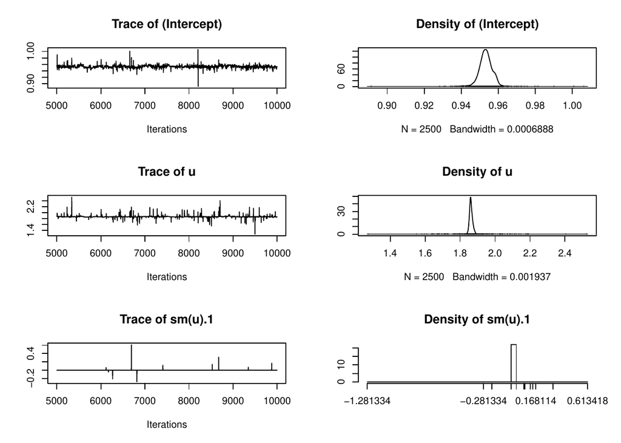

Figure 1: Trace and density plots for the regression coefficients $\beta_0, \beta_1$ and $\beta_2$ of the first simulated example. Parameters $\beta_1$ and $\beta_2$ are the coefficients of the first two basis functions, denoted by “u” and “sm(u).1”. Plots for coefficients $\beta_3,\dots,\beta_{21}$ are omitted as they follow a very similar pattern to that seen for $\beta_2$ (i.e., most of the time they take value zero but with random spikes away from zero).

Summaries of `mvrm` fits may be obtained utilizing functions `print.mvrm` and `summary.mvrm`. The method `print` takes as input an object of class `"mvrm"`. It returns basic information of the model fit, as shown below:

```r
> print(m1)

Call:
mvrm(formula = model, data = data, sweeps = 10000, burn = 5000,
    thin = 2, seed = 1, StorageDir = DIR, c.betaPrior = "IG(0.5,0.5*n)",
    c.alphaPrior = "IG(1.1,1.1)", pi.muPrior = "Beta(1,1)",
    pi.sigmaPrior = "Beta(1,1)", sigmaPrior = "HN(2)")

2500 posterior samples

Mean model - marginal inclusion probabilities
       u  sm(u).1  sm(u).2  sm(u).3  sm(u).4  sm(u).5  sm(u).6  sm(u).7
  1.0000   0.0040   0.0036   0.0032   0.0084   0.0036   0.0044   0.0028
 sm(u).8  sm(u).9 sm(u).10 sm(u).11 sm(u).12 sm(u).13 sm(u).14 sm(u).15
  0.0060   0.0020   0.0060   0.0036   0.0056   0.0056   0.0036   0.0052
sm(u).16 sm(u).17 sm(u).18 sm(u).19 sm(u).20
  0.0060   0.0044   0.0056   0.0044   0.0052

Variance model - marginal inclusion probabilities
       u  sm(u).1  sm(u).2  sm(u).3  sm(u).4  sm(u).5  sm(u).6  sm(u).7
  1.0000   0.6072   0.5164   0.5808   0.5488   0.6760   0.5320   0.6336
 sm(u).8  sm(u).9 sm(u).10 sm(u).11 sm(u).12 sm(u).13 sm(u).14 sm(u).15
  0.6936   0.6708   0.5996   0.4816   0.4912   0.3728   0.6268   0.5688
sm(u).16 sm(u).17 sm(u).18 sm(u).19 sm(u).20
  0.5872   0.6528   0.4428   0.6900   0.5356
```

The function returns a matched call, the number of posterior samples obtained, and marginal inclusion probabilities of the terms in the mean and variance models.

Whereas the output of the `print` method focuses on marginal inclusion probabilities, the output of the `summary` method focuses on the most frequently visited models. It takes as input an object of class `"mvrm"` and the number of (most frequently visited) models to be displayed, which by default is set to `nModels = 5`. Here to economize space we set `nModels = 2`. The information returned by the `summary` method is shown below

```r
> summary(m1, nModels = 2)

Specified model for the mean and variance:
y ~ sm(u, k = 20, bs = "rd") | sm(u, k = 20, bs = "rd")

Specified priors:
[1] c.beta = IG(0.5,0.5*n) c.alpha = IG(1.1,1.1)  pi.mu = Beta(1,1)
[4] pi.sigma = Beta(1,1)   sigma = HN(2)

Total posterior samples: 2500 ; burn-in: 5000 ; thinning: 2

Files stored in /home/papgeo/1/

Null deviance:           1299.292
Mean posterior deviance:  -88.691

Joint mean/variance model posterior probabilities:
  mean.u mean.sm.u..1 mean.sm.u..2 mean.sm.u..3 mean.sm.u..4 mean.sm.u..5
1      1            0            0            0            0            0
2      1            0            0            0            0            0
  mean.sm.u..6 mean.sm.u..7 mean.sm.u..8 mean.sm.u..9 mean.sm.u..10
1            0            0            0            0             0
2            0            0            0            0             0
  mean.sm.u..11 mean.sm.u..12 mean.sm.u..13 mean.sm.u..14 mean.sm.u..15
1             0             0             0             0             0
2             0             0             0             0             0
  mean.sm.u..16 mean.sm.u..17 mean.sm.u..18 mean.sm.u..19 mean.sm.u..20 var.u
1             0             0             0             0             0     1
2             0             0             0             0             0     1
  var.sm.u..1 var.sm.u..2 var.sm.u..3 var.sm.u..4 var.sm.u..5 var.sm.u..6
1           1           1           1           1           1           1
2           1           0           1           1           1           1
  var.sm.u..7 var.sm.u..8 var.sm.u..9 var.sm.u..10 var.sm.u..11 var.sm.u..12
1           1           1           1            0            1            0
2           1           1           1            1            1            1
  var.sm.u..13 var.sm.u..14 var.sm.u..15 var.sm.u..16 var.sm.u..17 var.sm.u..18
1            1            1            1            1            1            1
2            0            1            1            1            1            0
  var.sm.u..19 var.sm.u..20 freq prob cumulative
1            1            1  141 5.64       5.64
2            1            0  120 4.80      10.44
Displaying 2 models of the 916 visited
2 models account for 10.44% of the posterior mass
```

We next describe the function `plot.mvrm` which creates plots of terms in the mean and variance functions. Two calls to the `plot` method can be seen in the code below. Argument `x` expects an object of class `"mvrm"`, as created by a call to the function `mvrm`. The `model` argument may take on one of three possible values: `"mean"`, `"stdev"`, or `"both"`, specifying the model to be visualized. Further, the `term` argument determines the term to be plotted. In the current example there is only one term in each of the two models which leaves us with only one choice, `term = "sm(u)"`. Equivalently, `term` may be specified as an integer, `term = 1`. If `term` is left unspecified, then, by default, the first term in the model is plotted. For creating two-dimensional plots, as in the current example, the `plot` method utilizes the package *ggplot2*. Users of *BNSP* may add their own options to plots via the argument `plotOptions`. The code below serves as an example.

```r
> x1 <- seq(0, 1, length.out = 30)
> plotOptionsM <- list(geom_line(aes_string(x = x1, y = mu(x1)), col = 2, alpha = 0.5,
+                      lty = 2), geom_point(data = data, aes(x = u, y = y)))
> plot(x = m1, model = "mean", term = "sm(u)", plotOptions = plotOptionsM,
+      intercept = TRUE, quantiles = c(0.005, 0.995), grid = 30)
> plotOptionsV = list(geom_line(aes_string(x = x1, y = stdev(x1)), col = 2,
+                     alpha = 0.5, lty = 2))
> plot(x = m1, model = "stdev", term = "sm(u)", plotOptions = plotOptionsV,
+      intercept = TRUE, quantiles = c(0.05, 0.95), grid = 30)
```

The resulting plots can be seen in Figure 2, panels (a) and (b). Panel (a) displays the simulated dataset, showing the expected increase in both the mean and variance with increasing values of the covariate $u$. Further, we see the posterior mean of $\mu(u) = \beta_0 + f_{\mu}(u) = \beta_0 + \sum_{j=1}^{21} \beta_{j} \phi_{1j}(u)$ evaluated over a grid of $30$ values of $u$, as specified by the (default) `grid = 30` option for `plot`. For each sample ${\mathbf{\beta }}^{(s)}, s=1,\dots,S,$ from the posterior of ${\mathbf{\beta }}$, and for each value of $u$ over the grid of $30$ values, $u_j, j=1,\dots,30,$ the `plot` method computes $\mu(u_j)^{(s)} = \beta_0^{(s)} + \sum_{j=1}^{21} \beta_{j}^{(s)} \phi_{1j}(u_j)$. The default option `intercept = TRUE` specifies that the intercept $\beta_0$ is included in the computation, but it may be removed by setting `intercept = FALSE`. The posterior means are computed by the usual $\bar{\mu}(u_j) = S^{-1}\sum_{s} \mu(u_j)^{(s)}$ and are plotted with solid (blue-color) line. By default, the function displays $80\%$ point-wise credible intervals (CI). In Figure 2, panel (a) we have plotted $99\%$ CIs, as specified by option `quantiles = c(0.005, 0.995)`. This option specifies that for each value $u_j, j=1,\dots,30,$ on the grid, $99\%$ CIs for $\mu(u_j)$ are computed by the $0.5\%$ and $99.5\%$ quantiles of the samples $\mu(u_j)^{(s)}, s=1,\dots,S$. Plots without credible intervals may be obtained by setting `quantiles = NULL`.

Figure 2, panel (b) displays the posterior mean of the standard deviation function $\sigma(u) = \sigma \exp\{\sum_{j=1}^{q_2} \alpha_{j} \phi_{2j}(u)/2\}$. The details are the same as for the plot of the mean function, so here we briefly mention a difference: option `intercept = TRUE` specifies that $\sigma$ is included in the calculation. It may be removed by setting `intercept = FALSE`, which will result in plots of $\sigma(u)^{*} = \exp\{\sum_{j=1}^{q_2} \alpha_{j} \phi_{2j}(u)/2\}$.

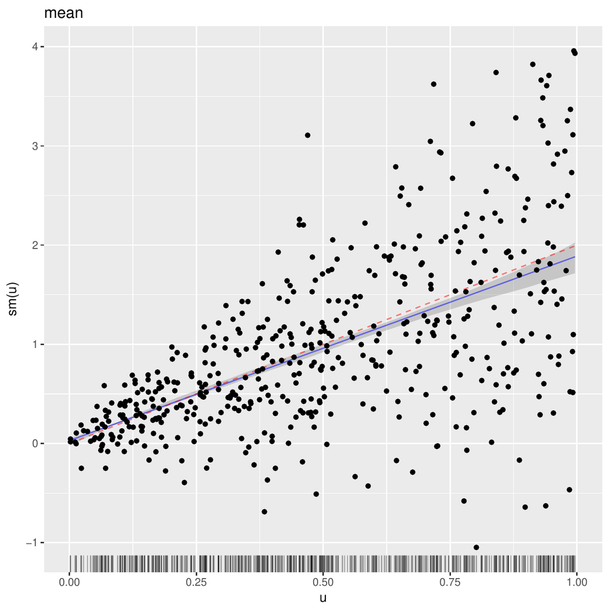

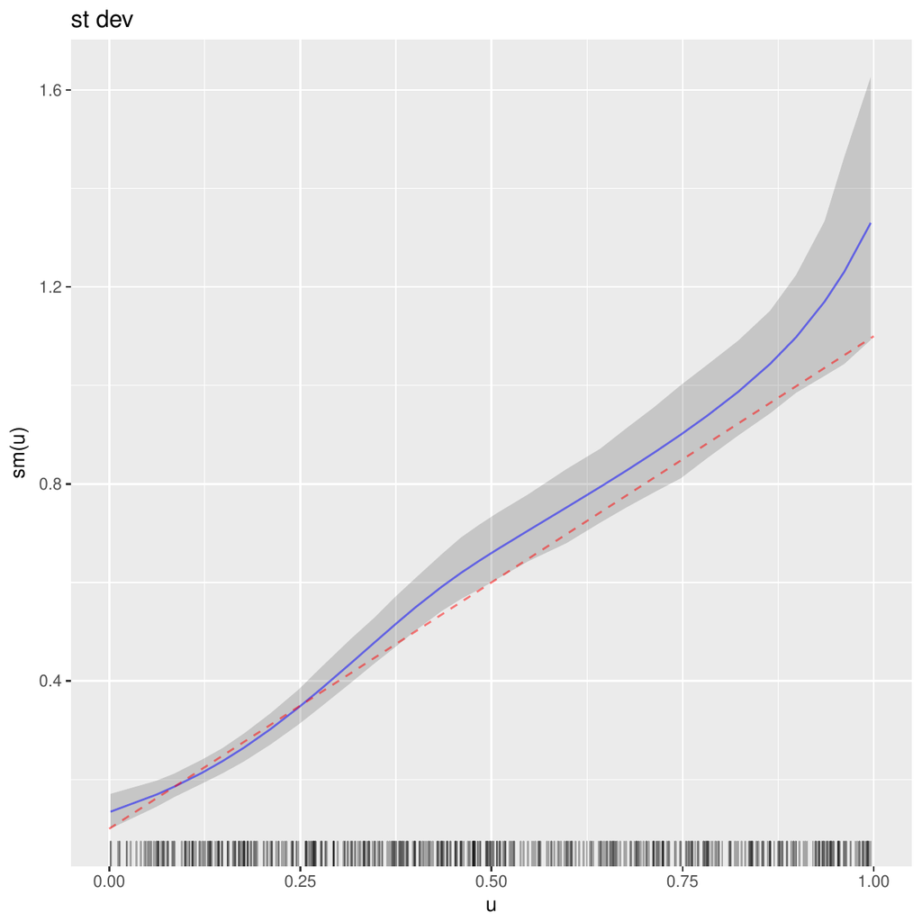

(a)

(b)

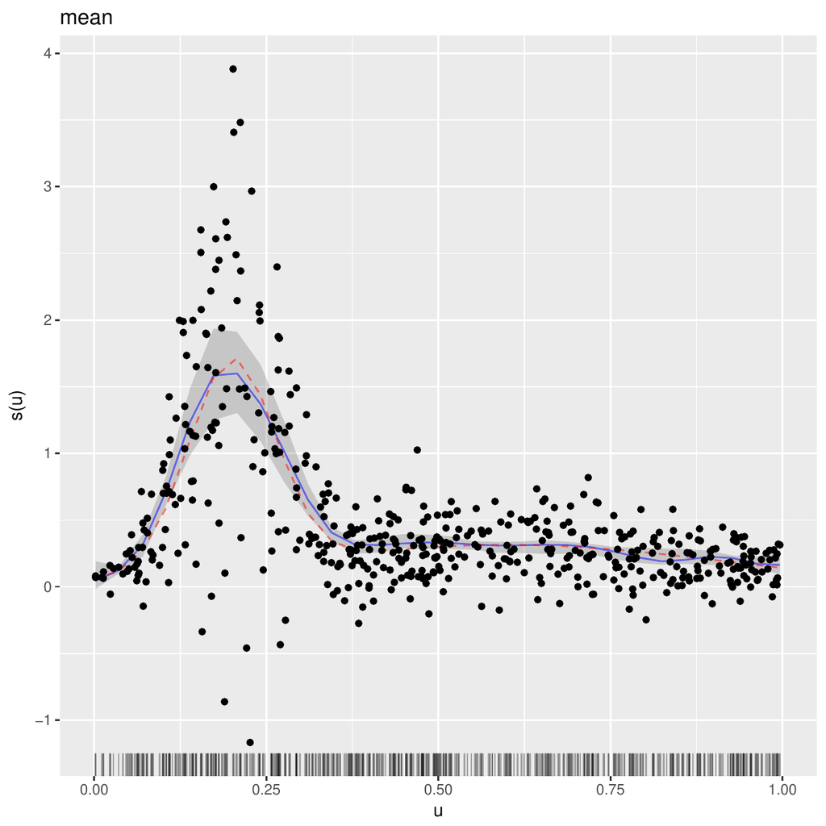

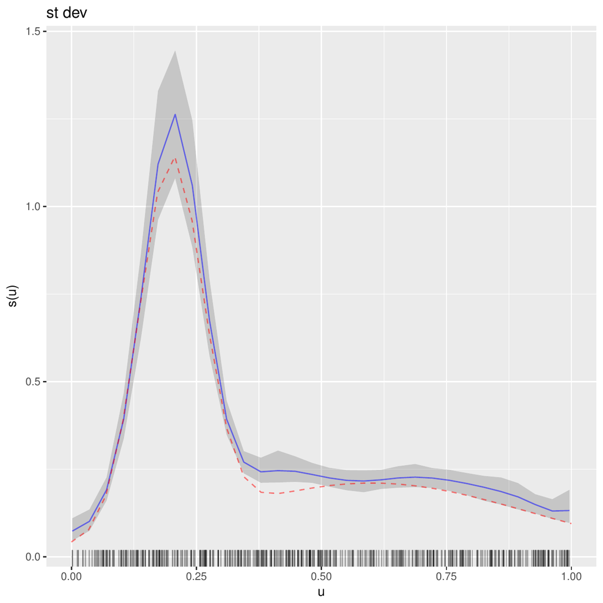

(c)

(d)

Figure 2: Results from the single covariate simulated examples. The column on the left-hand side displays the generated data points and posterior means of the estimated effect along with $99%$ CIs. The column on the right-hand side displays the posterior mean of the estimated standard deviation function along with $90%$ CIs. In all panels, the truth is represented by dashed (red color) lines, the posterior means by solid (blue color) lines, and the CIs by gray color.

We use the second simulated dataset to show how the `s` constructor from the package *mgcv* may be used. In our example, we use `s` to specify the model:

```r
> model <- y ~ s(u, k = 15, bs = "ps", absorb.cons=TRUE) |
+              s(u, k = 15, bs = "ps", absorb.cons=TRUE)
```

Function `BNSP::s` calls in turn `mgcv::s` and `mgcv::smoothCon`. All options of the last two functions may be passed to `BNSP::s`. In the example above we used options `k`, `bs`, and `absorb.cons`.

The remaining R code for the second simulated example is precisely the same as the one for the first example, and hence omitted. Results are shown in Figure 2, panels (c) and (d).

We conclude the current section by describing the function `predict.mvrm`. The function provides predictions and posterior credible or prediction intervals for given feature vectors. The two types of intervals differ in the associated level of uncertainty: prediction intervals attempt to capture a future response and are usually much wider than credible intervals that attempt to capture a mean response.

The following code shows how credible and prediction intervals can be obtained for a sequence of covariate values stored in `x1`

```r
> x1 <- seq(0, 1, length.out = 30)
> p1 <- predict(m1, newdata = data.frame(u = x1), interval = "credible")
> p2 <- predict(m1, newdata = data.frame(u = x1), interval = "prediction")
```

where the first argument in the `predict` method is a fitted `mvrm` model, the second one is a data frame containing the feature vectors at which predictions are to be obtained and the last one defines the type of interval to be created. We applied the `predict` method to the two simulated datasets. To each of those datasets we fitted two models: the first one is the one we saw earlier, where both the mean and variance are modeled in terms of covariates, while the second one ignores the dependence of the variance on the covariate. The latter model is specified in R using

```r
> model <- y ~ sm(u, k = 20, bs = "rd") | 1
```

Results are displayed in Figure 3. Each of the two figures displays a credible interval and two prediction intervals. The figure emphasizes a point that was discussed in the introductory section, that modeling the variance in terms of covariates can result in more realistic prediction intervals. The same point was recently discussed by Mayr et al. (2012).

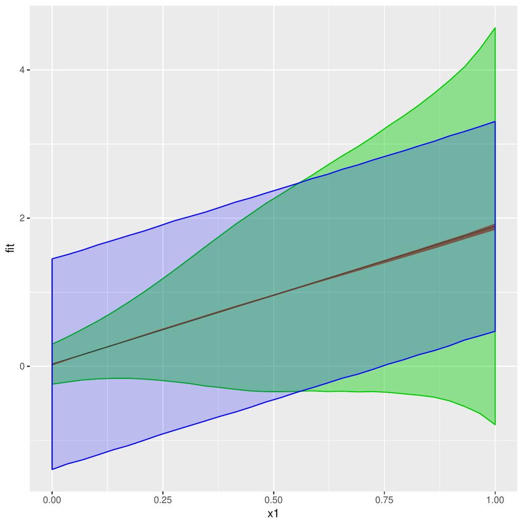

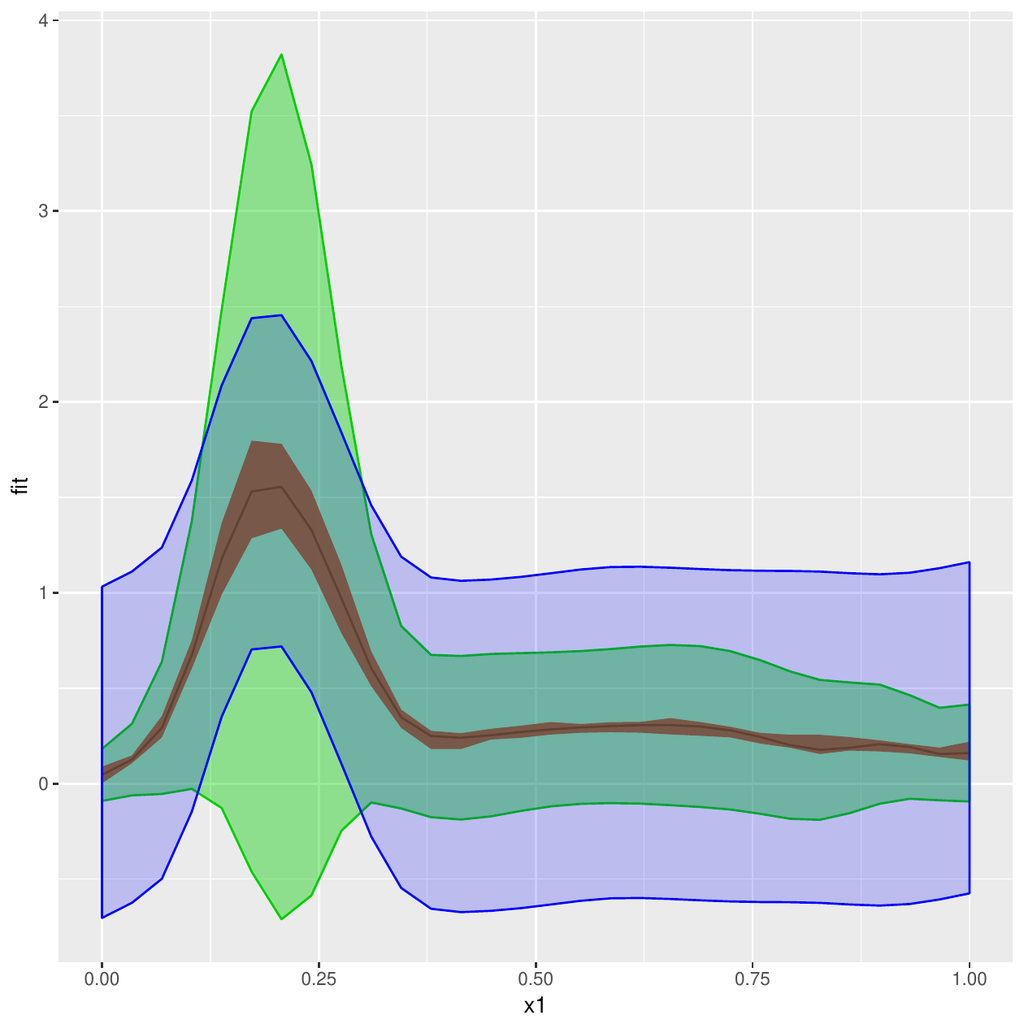

(a)

(b)

Figure 3: Predictions results from the first two simulated datasets. Each panel displays a credible interval and two prediction intervals, one obtained using a model that recognizes the dependence of the variance on the covariate and one that ignores it.

### Bivariate covariate case

Interactions between two predictors can be modeled by appropriate specification of either the built-in `sm` function or the smooth constructors from *mgcv*. Function `sm` can take up to two covariates, both of which may be continuous or one continuous and one discrete. Next we consider an example that involves two continuous covariates. An example involving a continuous and a discrete covariate is shown later on, in the second application to a real dataset.

Let ${\mathbf{u}} =(u_1,u_2)^{\top}$ denote a bivariate predictor. The data-generating mechanism that we consider is
$$\begin{aligned}
&& y({\mathbf{u}} ) \sim N\{\mu({\mathbf{u}}
),\sigma^2({\mathbf{u}} )\}, \nonumber\\
&& \mu({\mathbf{u}} ) = 0.1 + N\left({\mathbf{u}} , {\mathbf{\mu
}}_1, {\mathbf{\Sigma }}_1 \right) + N\left({\mathbf{u}} , {\mathbf{\mu
}}_2, {\mathbf{\Sigma }}_2\right), \nonumber\\
&& \sigma^2({\mathbf{u}} ) = 0.1 + \left\{N\left({\mathbf{u}} ,
{\mathbf{\mu }}_1, {\mathbf{\Sigma }}_1 \right) + N\left({\mathbf{u}} ,
{\mathbf{\mu }}_2, {\mathbf{\Sigma }}_2\right)\right\}/2, \nonumber\\
&& {\mathbf{\mu }}_1 = \begin{pmatrix} 0.25 \\ 0.75
\end{pmatrix},
{\mathbf{\Sigma }}_1 = \begin{pmatrix} 0.03 & 0.01 \\ 0.01 &
0.03 \end{pmatrix},
{\mathbf{\mu }}_2 = \begin{pmatrix} 0.65 \\ 0.35 \end{pmatrix},
{\mathbf{\Sigma }}_2 = \begin{pmatrix} 0.09 & 0.01 \\ 0.01 &
0.09 \end{pmatrix}.\nonumber
\end{aligned}$$
As before, $u_1$ and $u_2$ are obtained independently from uniform distributions on the unit interval. Further, the sample size is set to $n=500$.

In R, we simulate data from the above mechanism using

```r
> mu1 <- matrix(c(0.25, 0.75))
> sigma1 <- matrix(c(0.03, 0.01, 0.01, 0.03), 2, 2)
> mu2 <- matrix(c(0.65, 0.35))
> sigma2 <- matrix(c(0.09, 0.01, 0.01, 0.09), 2, 2)
> mu <- function(x1, x2) {x <- cbind(x1, x2);
+       0.1 + dmvnorm(x, mu1, sigma1) + dmvnorm(x, mu2, sigma2)}
> Sigma <- function(x1, x2) {x <- cbind(x1, x2);
+          0.1 + (dmvnorm(x, mu1, sigma1) + dmvnorm(x, mu2, sigma2)) / 2}
> set.seed(1)
> n <- 500
> w1 <- runif(n)
> w2 <- runif(n)
> y <- vector()
> for (i in 1:n) y[i] <- rnorm(1, mean = mu(w1[i], w2[i]),
+                              sd = sqrt(Sigma(w1[i], w2[i])))
> data <- data.frame(y, w1, w2)
```

We fit a model with mean and variance functions specified as
$$\begin{aligned}
\mu({\mathbf{u}} ) = \beta_0 + \sum_{j_1=1}^{12} \sum_{j_2=1}^{12}
\beta_{j_1,j_2} \phi_{1j_1,j_2}({\mathbf{u}} ), \quad
\log(\sigma^2({\mathbf{u}} )) = \alpha_0 + \sum_{j_1=1}^{12}
\sum_{j_2=1}^{12} \alpha_{j_1,j_2} \phi_{2j_1,j_2}({\mathbf{u}} ).
\nonumber\label{modelsim2}
\end{aligned} (\#eq:modelsim2)$$
The R code that fits the above model is

```r
> Model <- y ~ sm(w1, w2, k = 10, bs = "rd") | sm(w1, w2, k = 10, bs = "rd")
> m2 <- mvrm(formula = Model, data = data, sweeps = 10000, burn = 5000, thin = 2,
+            seed = 1, StorageDir = DIR)
```

As in the univariate case, convergence assessment and univariate posterior summaries may be obtained by using function `mvrm2mcmc` in conjunction with functions `plot.mcmc` and `summary.mcmc`. Further, summaries of the `mvrm` fits may be obtained using functions `print.mvrm` and `summary.mvrm`. Plots of the bivariate effects may be obtained using function `plot.mvrm`. This is shown below, where argument `plotOptions` utilizes the package [*colorspace*](https://CRAN.R-project.org/package=colorspace) (Zeileis, Hornik, and Murrell 2009).

```r
> plot(x = m2, model = "mean", term = "sm(w1,w2)", static = TRUE,
+      plotOptions = list(col = diverge_hcl(n = 10)))
> plot(x = m2, model = "stdev", term = "sm(w1,w2)", static = TRUE,
+      plotOptions = list(col = diverge_hcl(n = 10)))
```

Results are shown in Figure 4. For bivariate predictors, function `plot.mvrm` calls function `ribbon3D` from the package *plot3D*. Dynamic plots, viewable in a browser, can be created by replacing the default `static=TRUE` by `static=FALSE`. When the latter option is specified, function `plot.mvrm` calls the function `scatterplot3js` from the package *threejs*. Users may pass their own options to `plot.mvrm` via the `plotOptions` argument.

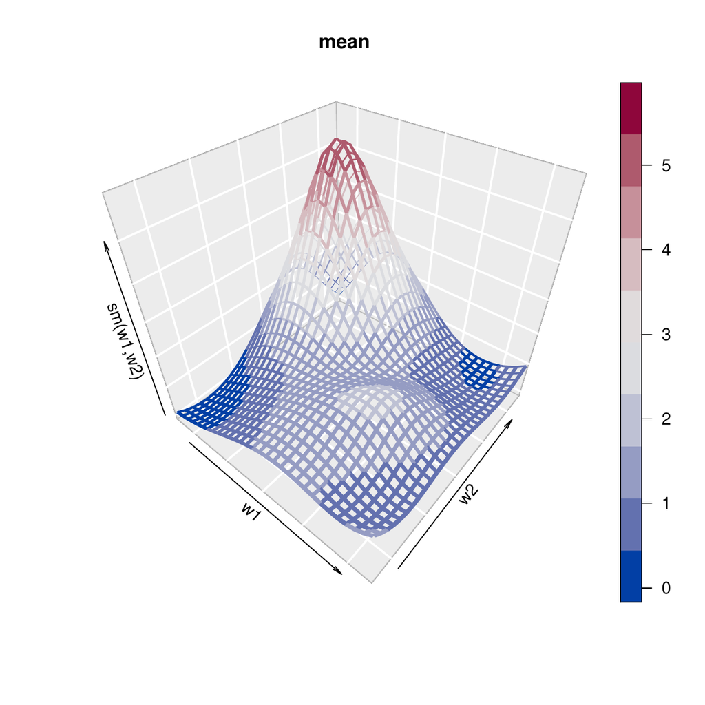

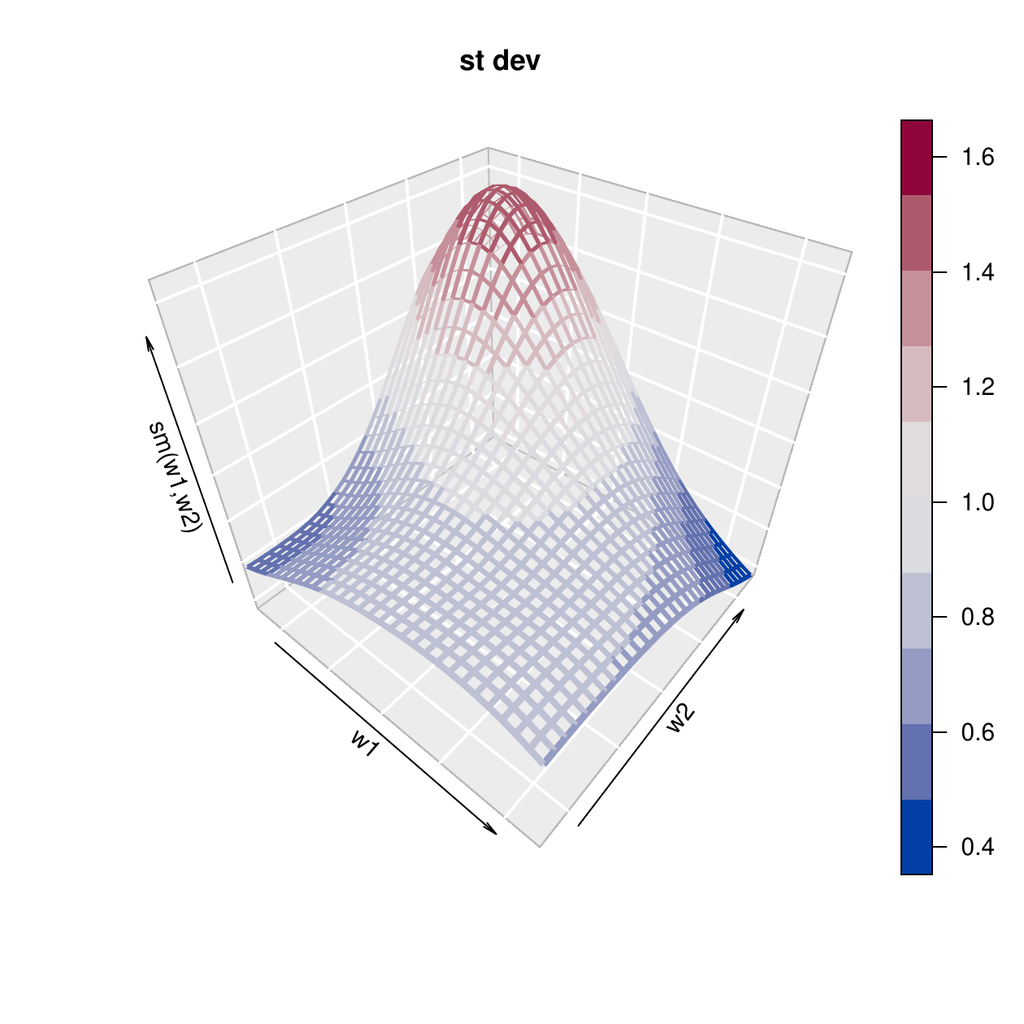

(a)

(b)

Figure 4: Bivariate simulation study results with two continuous covariates. Shown are posterior means of (a) the mean and (b) the standard deviation function.

### Multiple covariate case

We consider fitting general additive models for the mean and variance functions in a simulated example with four independent continuous covariates. In this scenario, we set $n=1000$. Further the covariates ${\mathbf{w}} =(w_1,w_2,w_3,w_4)^{\top}$ are simulated independently from a uniform distribution on the unit interval. The data-generating mechanism that we consider is
$$\begin{aligned}
&& Y({\mathbf{w}} ) \sim N(\mu({\mathbf{w}}
),\sigma^2({\mathbf{w}} )), \nonumber \\
&& \mu({\mathbf{w}} ) = \sum_{j=1}^4 \mu_j(w_j) \quad \text{and}
\quad \sigma({\mathbf{w}} ) = \prod_{j=1}^4 \sigma_j(w_j), \nonumber
\end{aligned}$$
where functions $\mu_j, \sigma_j, j=1,\dots,4,$ are specified below:

1. $\mu_1(w_1) = 1.5 w_1, \sigma_1(w_1)=\left\{N(w_1,\mu=0.2,\sigma^2=0.004)+N(w_1,\mu=0.6,\sigma^2=0.1)\right\}/2$,
2. $\mu_2(w_2) = \left\{N(w_2,\mu=0.2,\sigma^2=0.004)+N(w_2,\mu=0.6,\sigma^2=0.1)\right\}/2,$  
   $\sigma_2(w_2)=0.6+0.5\sin(2 \pi w_2)$,
3. $\mu_3(w_3) = 1+ \sin(2 \pi w_3), \sigma_3(w_3)=1.1-w_3$,
4. $\mu_4(w_4) = -w_4, \sigma_4(w_4)=0.2+1.5w_4$.

To the generated dataset we fit a model with mean and variance functions modeled as
$$\begin{aligned}
\mu({\mathbf{w}} ) = \beta_0 + \sum_{k=1}^{4} \sum_{j=1}^{16} \beta_{kj}
\phi_{kj}(w_k) \quad \text{and} \quad
\log\{\sigma^2({\mathbf{w}} )\} = \alpha_0 + \sum_{k=1}^{4}
\sum_{j=1}^{16} \alpha_{kj} \phi_{kj}(w_k). \nonumber\label{modelsim3}
\end{aligned} (\#eq:modelsim3)$$
Fitting the above model to the simulated data is achieved by the following R code

```r
> Model <- y ~ sm(w1, k = 15, bs = "rd") + sm(w2, k = 15, bs = "rd") +
+              sm(w3, k = 15, bs = "rd") + sm(w4, k = 15, bs = "rd") |
+              sm(w1, k = 15, bs = "rd") + sm(w2, k = 15, bs = "rd") +
+              sm(w3, k = 15, bs = "rd") + sm(w4, k = 15, bs = "rd")
> m3 <- mvrm(formula = Model, data = data, sweeps = 50000, burn = 25000,
+            thin = 5, seed = 1, StorageDir = DIR)
```

By default the function `sm` utilizes the radial basis functions, hence there is no need to specify `bs = "rd"`, as we did earlier, if radial basis functions are preferred over thin plate splines. Further, we have selected `k = 15` for all smooth functions. However, there is no restriction to the number of knots and certainly one can select a different number of knots for each smooth function.

As discussed previously, for each term that appears in the right-hand side of the mean and variance functions, the model incorporates indicator variables that specify which basis functions are to be included and which are to be excluded from the model. For the current example, the indicator variables are denoted by $\gamma_{kj}$ and $\delta_{kj}, k=1,2,3,4,j=1,\dots,16$. The prior probabilities that variables are included were specified in (@ref(eq:gam-priors)) and they are specific to each term, $\pi_{\mu_k} \sim \text{Beta}(c_{\mu_k},d_{\mu_k}), \quad \pi_{\sigma_k} \sim \text{Beta}(c_{\sigma_k},d_{\sigma_k}), k=1,2,3,4.$ The default option `pi.muPrior = "Beta(1,1)"` specifies that $\pi_{\mu_k} \sim \text{Beta}(1,1),k=1,2,3,4.$ Further, by setting, for example, `pi.muPrior = "Beta(2,1)"` we specify that $\pi_{\mu_k} \sim \text{Beta}(2,1),k=1,2,3,4.$ To specify a different Beta prior for each of the four terms, `pi.muPrior` will have to be specified as a vector of length four, as an example, `pi.muPrior = c("Beta(1,1)","Beta(2,1)","Beta(3,1)","Beta(4,1)")`. Specification of the priors for $\pi_{\sigma_k}$ is done in a similar way, via argument `pi.sigmaPrior`.

We conclude this section by presenting plots of the four terms in the mean and variance models. The plots are presented in Figure 5. We provide a few details on how the `plot` method works in the presence of multiple terms, and how the comparison between true and estimated effects is made. Starting with the mean function, to create the relevant plots, that appear on the left panels of Figure 5, the `plot` method considers only the part of the mean function $\mu({\mathbf{u}} )$ that is related to the chosen `term` while leaving all other terms out. For instance, in the code below we choose `term = "sm(u1)"` and hence we plot the posterior mean and a posterior credible interval for $\sum_{j=1}^{16} \beta_{1j} \phi_{1j}(u_1)$, where the intercept $\beta_0$ is left out by option `intercept = FALSE`. Further, comparison is made with a centered version of the true curve, represented by the dashed (red color) line and obtained by the first three lines of code below.

```r
> x1 <- seq(0, 1, length.out = 30)
> y1 <- mu1(x1)
> y1 <- y1 - mean(y1)
> PlotOptions <- list(geom_line(aes_string(x = x1, y = y1),
+                     col = 2, alpha = 0.5, lty = 2))
> plot(x = m3, model = "mean", term = "sm(w1)", plotOptions = PlotOptions,
+      intercept = FALSE, centreEffects = FALSE, quantiles = c(0.005, 1 - 0.005))
```

The plots of the four standard deviation terms are shown in the right panels of Figure 5. Again, these are created by considering only the part of the model for $\sigma({\mathbf{u}} )$ that is related to the chosen `term`. For instance, below we choose `term = "sm(u1)"`. Hence, in this case the plot will present the posterior mean and a posterior credible interval for $\exp\{\sum_{j=1}^{16} \alpha_{1j} \phi_{1j}(u_1)/2\}$, where the intercept $\alpha_0$ is left out by option `intercept = FALSE`. Option `centreEffects = TRUE` scales the posterior realizations of $\exp\{\sum_{j=1}^{16} \alpha_{1j} \phi_{1j}(u_1)/2\}$ before plotting them, where the scaling is done in such a way that the realized function has mean one over the range of the predictor. Further, the comparison is made with a scaled version of the true curve, where again the scaling is done to achieve mean one. This is shown below and it is in the spirit of Chan et al. (2006) who discuss the differences between the data generating mechanism and the fitted model.

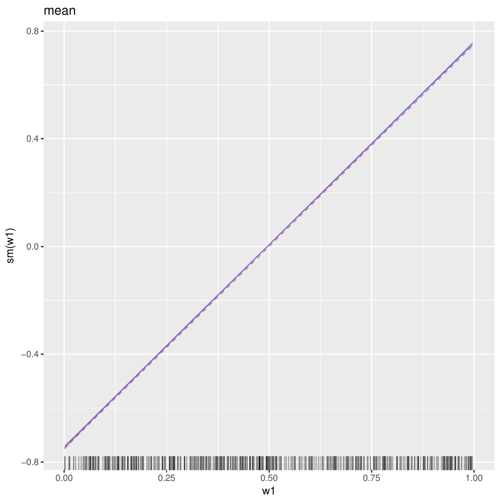

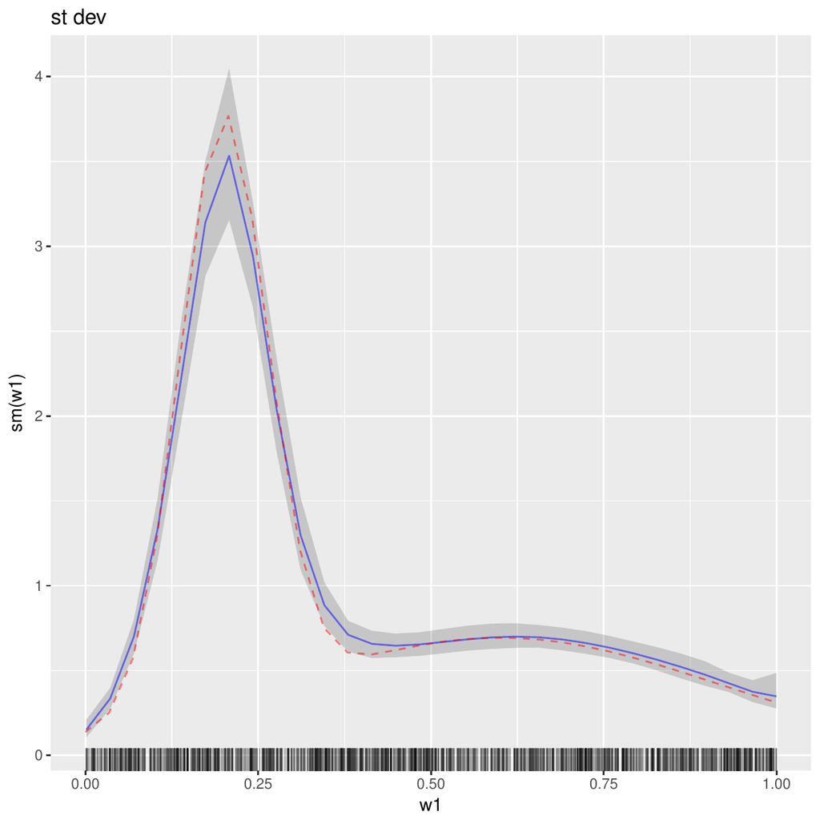

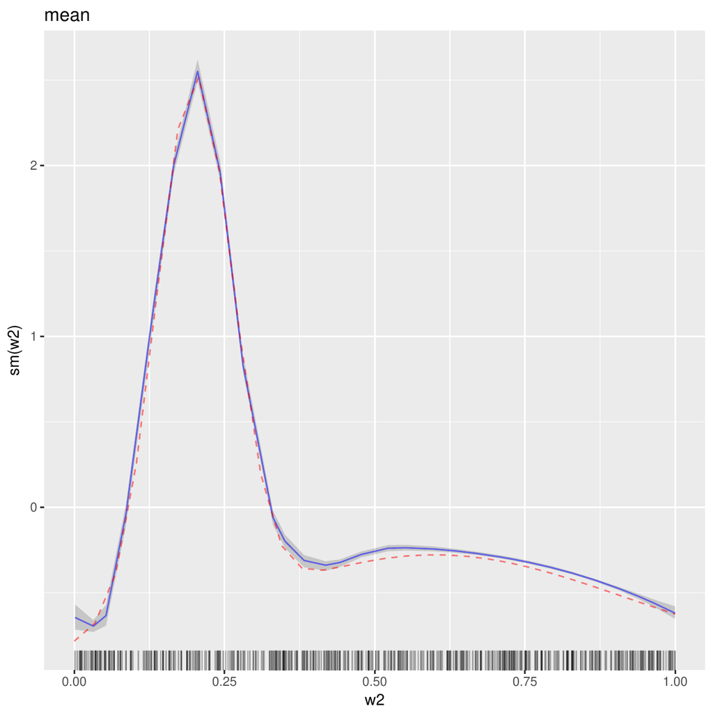

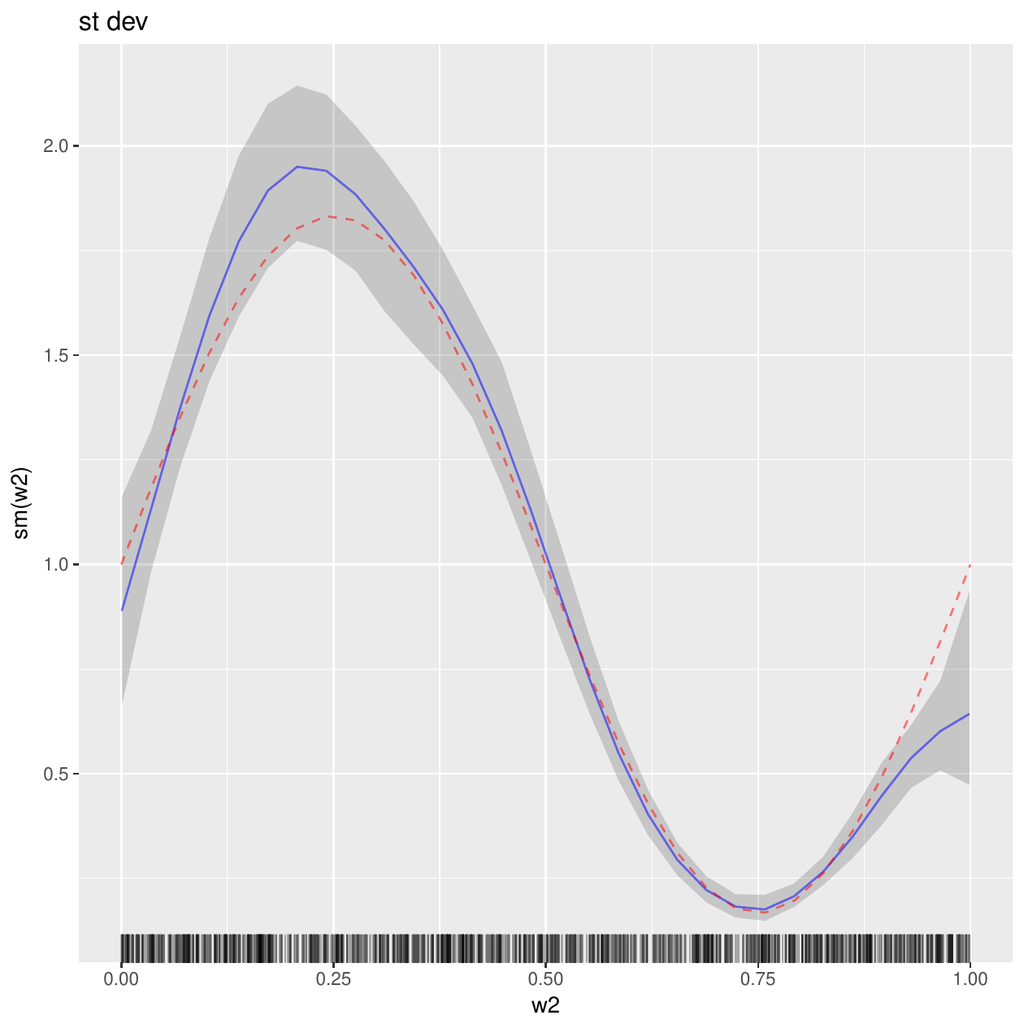

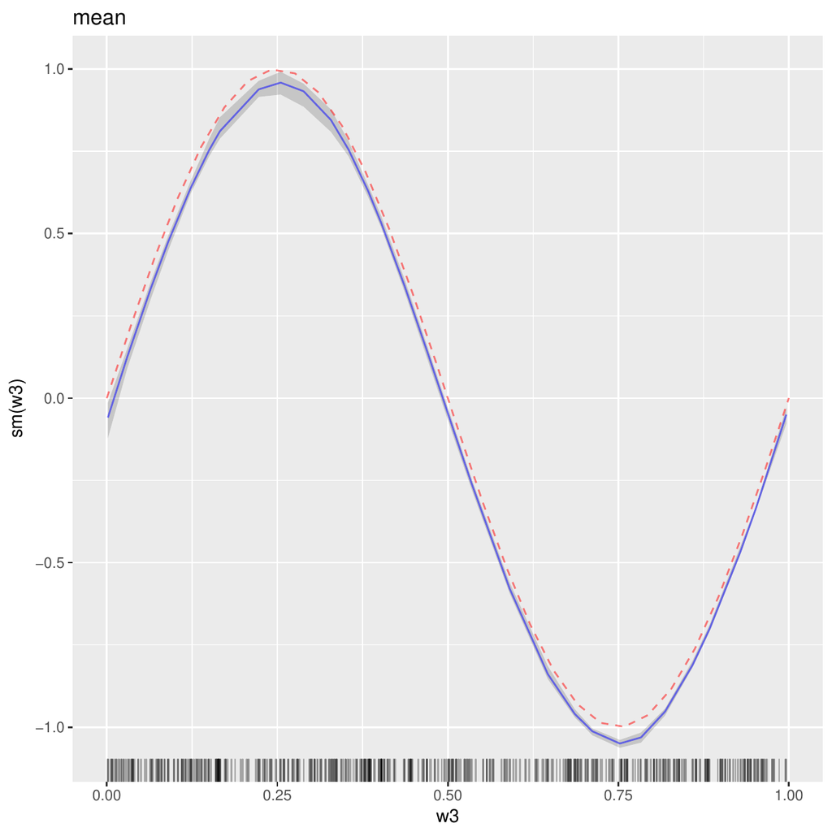

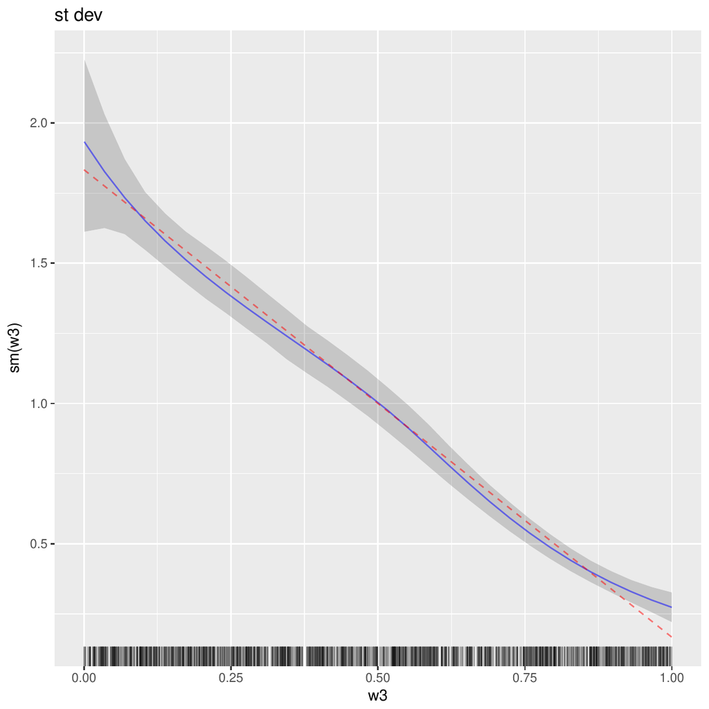

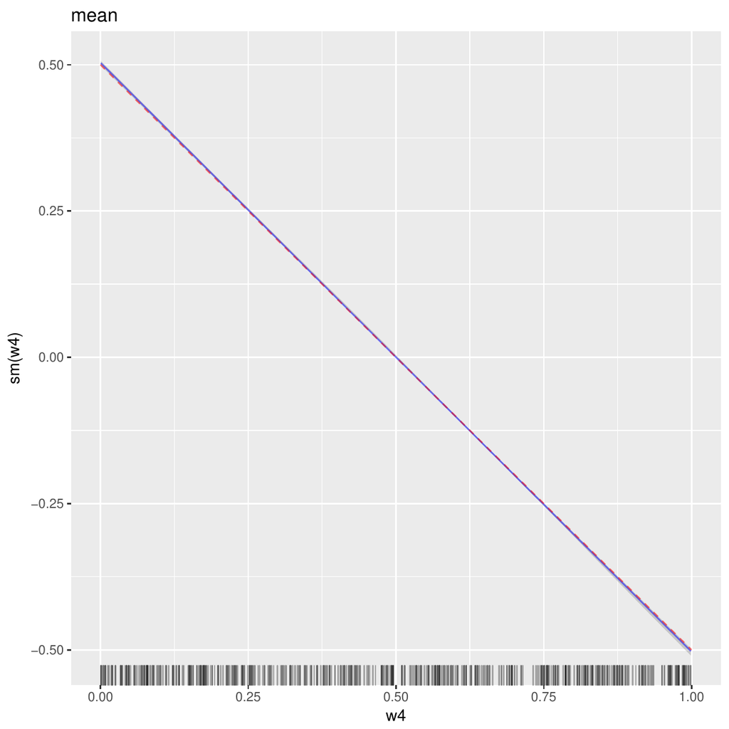

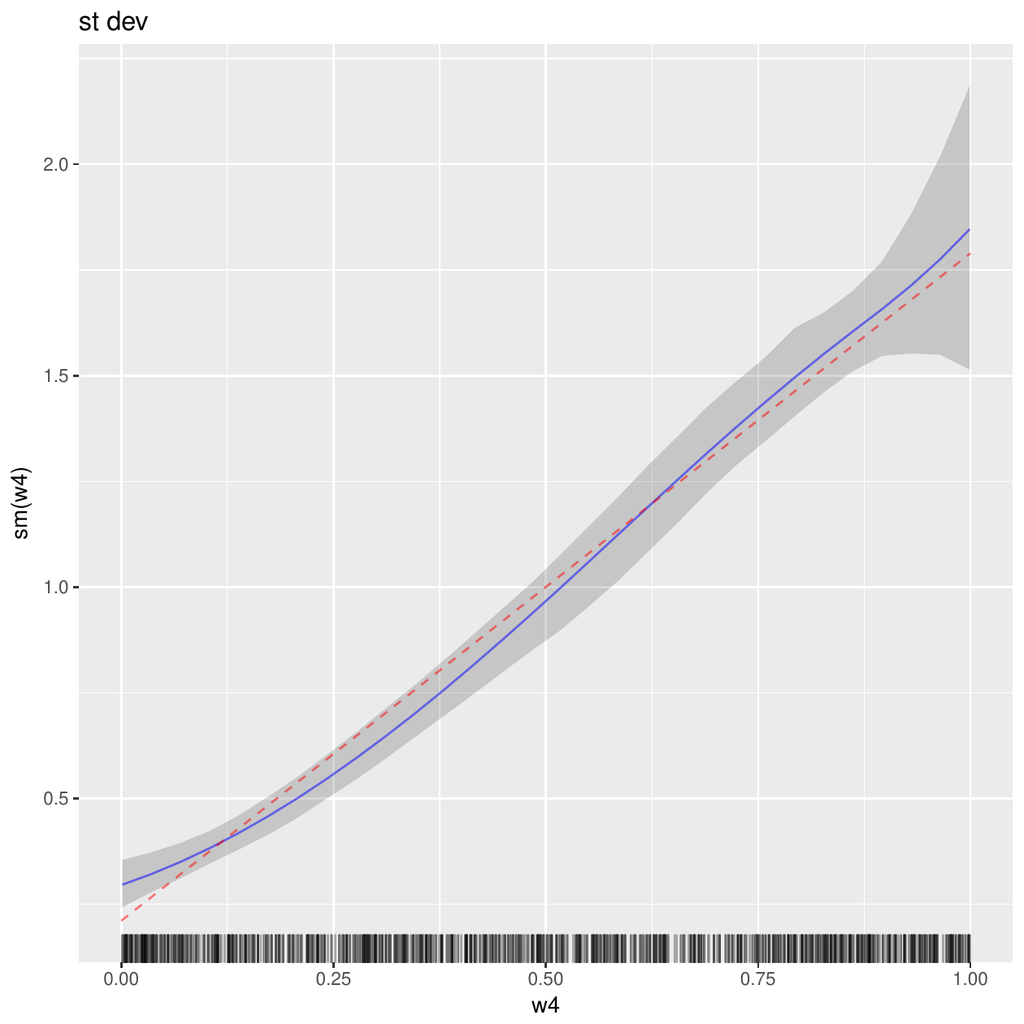

```r
> y1 <- stdev1(x1) / mean(stdev1(x1))
> PlotOptions <- list(geom_line(aes_string(x = x1, y = y1),
+                     col = 2, alpha = 0.5, lty = 2))
> plot(x = m3, model = "stdev", term = "sm(w1)", plotOptions = PlotOptions,
+      intercept = FALSE, centreEffects = TRUE, quantiles = c(0.025, 1 - 0.025))
```

## Data analyses

In this section we present four empirical applications.

### Wage and age

In the first empirical application, we analyse a dataset from Pagan and Ullah (1999) that is available in the R package [*np*](https://CRAN.R-project.org/package=np) (Hayfield and Racine 2008). The dataset consists of $n=205$ observations on dependent variable `logwage`, the logarithm of the individual’s wage, and covariate `age`, the individual’s age. The dataset comes from the 1971 Census of Canada Public Use Sample Tapes and the sampling units it involves are males of common education. Hence, the investigation of the relationship between age and the logarithm of wage is carried out controlling for the two potentially important covariates education and gender.

We utilize the following R code to specify flexible models for the mean and variance functions, and to obtain $5,000$ posterior samples, after a burn-in period of $25,000$ samples and a thinning period of $5$.

```r
> data(cps71)
> DIR <- getwd()
> model <- logwage ~ sm(age, k = 30, bs = "rd") | sm(age, k = 30, bs = "rd")
> m4 <- mvrm(formula = model, data = cps71, sweeps = 50000,
+            burn = 25000, thin = 5, seed = 1, StorageDir = DIR)
```

After checking convergence, we use the following code to create the plots that appear in Figure 6.

```r
> wagePlotOptions <- list(geom_point(data = cps71, aes(x = age, y = logwage)))
> plot(x = m4, model = "mean", term = "sm(age)", plotOptions = wagePlotOptions)
> plot(x = m4, model = "stdev", term = "sm(age)")
```

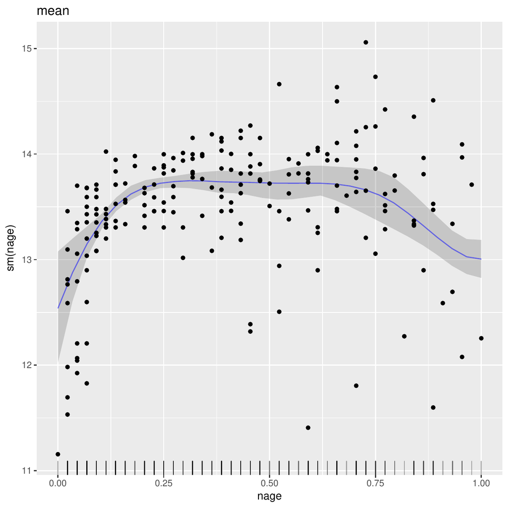

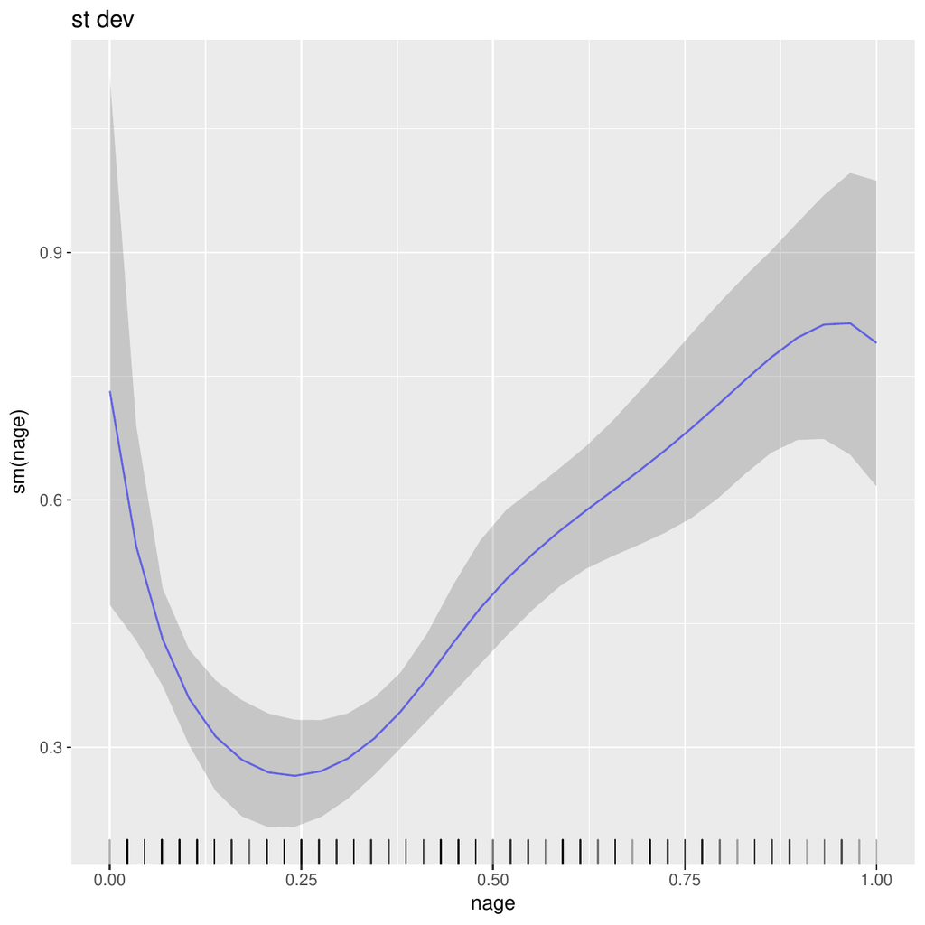

(a)

(b)

Figure 6: Results from the data analysis on the relationship between age and the logarithm of wage. Panel (a) shows the posterior mean, an $80%$ credible interval of the mean function, and the observed data-points. Panel (b) shows the posterior mean and an $80%$ credible interval of the standard deviation function.

### Wage and multiple covariates

In the second empirical application, we analyse a dataset from Wooldridge (2008) that is also available in the R package *np*. The response variable here is the logarithm of the individual’s hourly wage (`lwage`) while the covariates include the years of education (`educ`), the years of experience (`exper`), the years with the current employer (`tenure`), the individual’s gender (named as `female` within the dataset, with levels `Female` and `Male`), and marital status (named as `married` with levels `Married` and `Notmarried`). The dataset consists of $n=526$ independent observations. We analyse the first three covariates as continuous and the last two as discrete.

As the variance function is modeled in terms of an exponential, see (@ref(eq:mv2)), to avoid potential numerical problems, we transform the three continuous variables to have range in the interval $[0,1]$, using

```r
> data(wage1)
> wage1$ntenure <- wage1$tenure / max(wage1$tenure)
> wage1$nexper <- wage1$exper / max(wage1$exper)
> wage1$neduc <- wage1$educ / max(wage1$educ)
```

We choose to fit the following mean and variance models to the data
$$\begin{aligned}
&&\mu_i = \beta_0 + \beta_1 \;\texttt{married}_i+
f_1(\texttt{ntenure}_i) +
f_2(\texttt{neduc}_i) +
f_3(\texttt{nexper}_i,\texttt{female}_i), \nonumber\\
&&\log(\sigma^2_i) = \alpha_0 + f_4(\texttt{nexper}_i).
\nonumber
\end{aligned}$$
We note that, as it turns out, an interaction between variables `nexper` and `female` is not necessary for the current data analysis. However, we choose to add this term in the mean model in order to illustrate how interaction terms can be specified. We illustrate further options below.

```r
> knots1 <- seq(min(wage1$nexper), max(wage1$nexper), length.out = 30)
> knots2 <- c(0, 1)
> knotsD <- expand.grid(knots1, knots2)
> model <- lwage ~ fmarried + sm(ntenure) + sm(neduc, knots=data.frame(knots =
+ seq(min(wage1$neduc), max(wage1$neduc), length.out = 15))) +
+ sm(nexper, ffemale, knots = knotsD) | sm(nexper, knots=data.frame(knots =
+ seq(min(wage1$nexper), max(wage1$nexper), length.out=15)))
```

The first three lines of the R code above specify the matrix of (potential) knots to be used for representing $f_3(\texttt{nexper,female})$. Knots may be left unspecified, in which case the defaults in function `sm` will be used. Furthermore, in the specification of the mean model we use `sm(ntenure)`. By this, we chose to represent $f_1$ utilizing the default $10$ knots and the radial basis functions. Further, the specification of $f_2$ in the mean model illustrates how users can specify their own knots for univariate functions. In the current example, we select $15$ knots uniformly spread over the range of `neduc`. Fifteen knots are also used to represent $f_4$ within the variance model.

The following code is used to obtain samples from the posteriors of the model parameters.

```r
> DIR <- getwd()
> m5 <- mvrm(formula = model, data = wage1, sweeps = 100000,
+            burn = 25000, thin = 5, seed = 1, StorageDir = DIR))
```

After summarizing results and checking convergence, we create plots of posterior means, along with $95\%$ credible intervals, for functions $f_1,\dots,f_4$. These are displayed in Figure 7. As it turns out, variable `married` does not have an effect on the mean of `lwage`. For this reason, we do not provide further results on the posterior of the coefficient of covariate `married`, $\beta_1$. However, in the code below we show how graphical summaries on $\beta_1$ can be obtained, if needed.

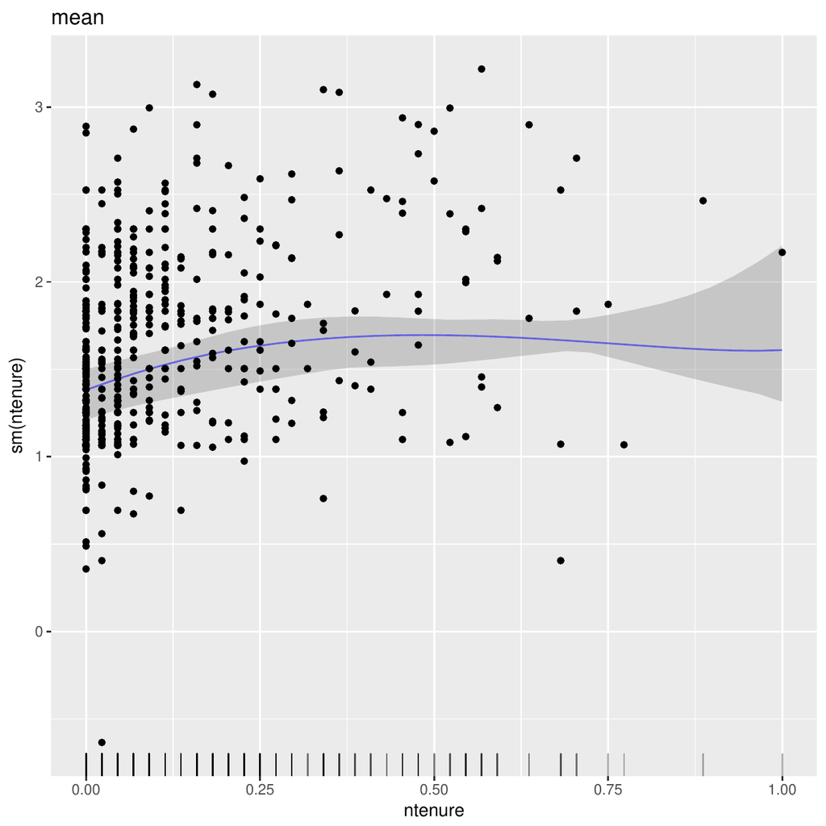

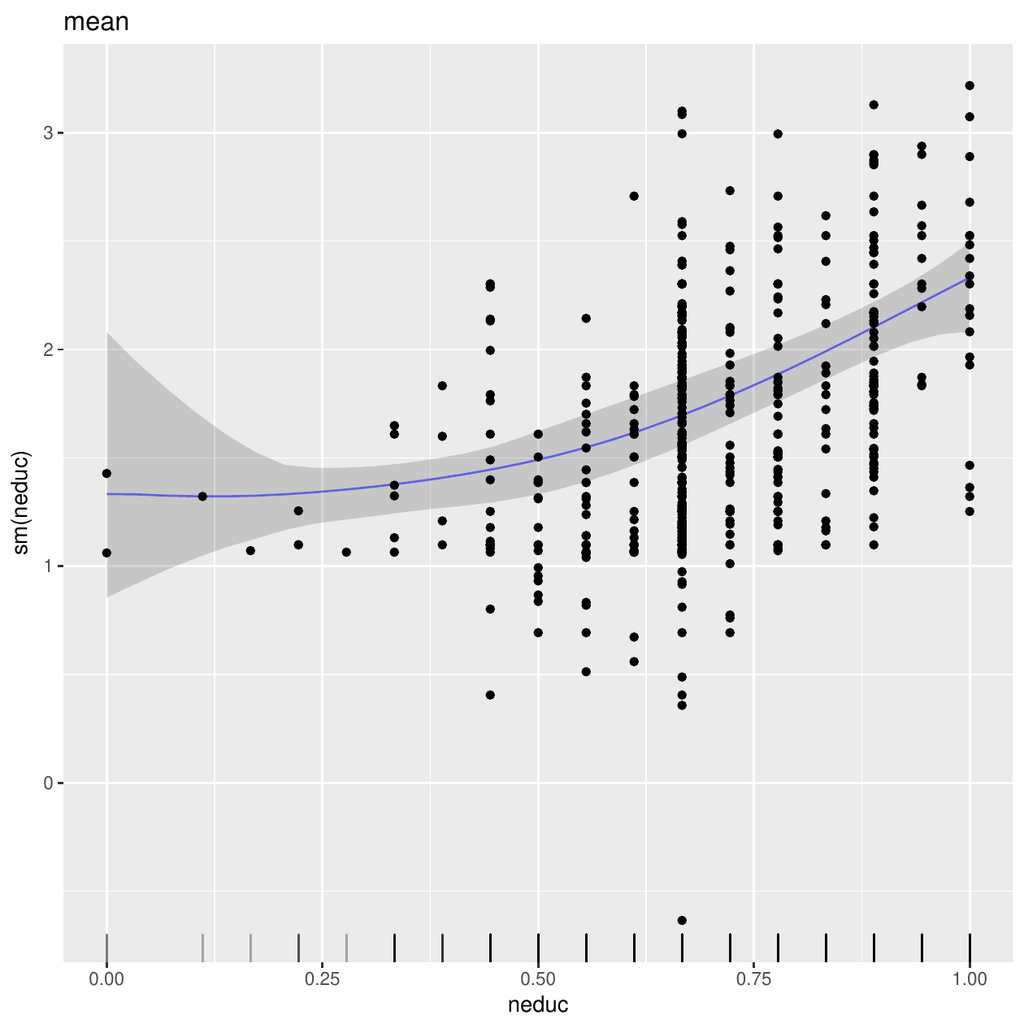

```r
> PlotOptionsT <- list(geom_point(data = wage1, aes(x = ntenure, y = lwage)))
> plot(x = m5, model = "mean", term="sm(ntenure)", quantiles = c(0.025, 0.975),
+      plotOptions = PlotOptionsT)
> PlotOptionsEdu <- list(geom_point(data = wage1, aes(x = neduc, y = lwage)))
> plot(x = m5, model = "mean", term = "sm(neduc)", quantiles = c(0.025, 0.975),
+      plotOptions = PlotOptionsEdu)
> pchs <- as.numeric(wage1$female)
> pchs[pchs == 1] <- 17; pchs[pchs == 2] <- 19
> cols <- as.numeric(wage1$female)
> cols[cols == 2] <- 3; cols[cols == 1] <- 2
> PlotOptionsE <- list(geom_point(data = wage1, aes(x = nexper, y = lwage),
+                      col = cols, pch = pchs, group = wage1$female))
> plot(x = m5, model = "mean", term="sm(nexper,female)", quantiles = c(0.025, 0.975),
+      plotOptions = PlotOptionsE)
> plot(x = m5, model = "stdev", term = "sm(nexper)", quantiles = c(0.025, 0.975))
> PlotOptionsF <- list(geom_boxplot(fill = 2, color = 1))
> plot(x = m5, model = "mean", term = "married", quantiles = c(0.025, 0.975),
+      plotOptions = PlotOptionsF)
```

(a)

(b)

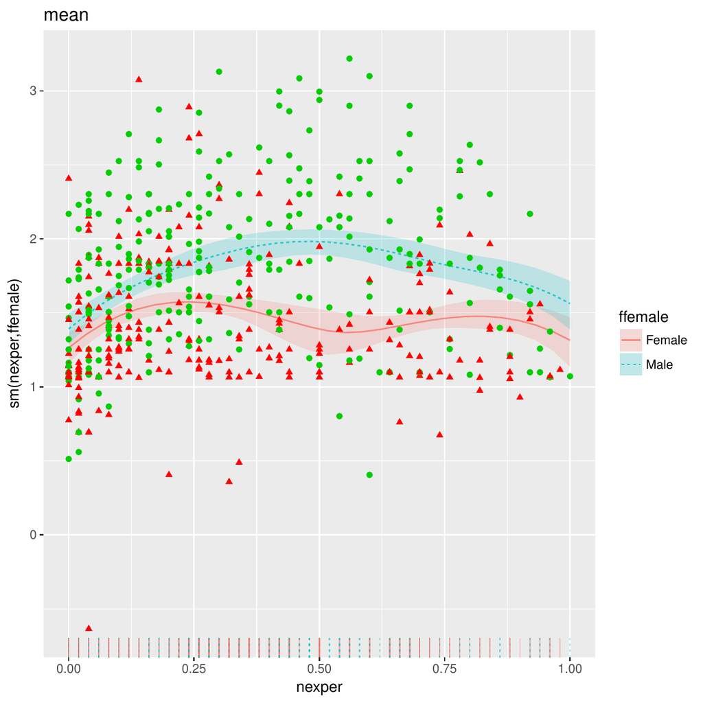

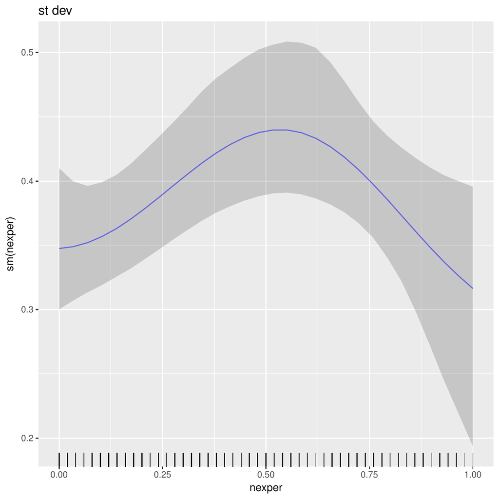

(c)

(d)

Figure 7: Results from the data analysis on the relationship between covariates gender, marital status, experience, education, and tenure, and response variable logarithm of hourly wage. Posterior means and $95%$ credible intervals for (a) *f*<sub>1</sub>(`ntenure`), (b) *f*<sub>2</sub>(`neduc`), (c) *f*<sub>3</sub>(`nexper`,`female`), and (d) the standard deviation function *σ*<sub>*i*</sub> = *σ*exp [*f*<sub>4</sub>(`nexper`)/2].

Figure 7, panels (a) and (b) show the posterior means and $95\%$ credible intervals for $f_1(\texttt{ntenure})$ and $f_2(\texttt{neduc})$. It can be seen that expected wages increase with tenure and education, although there is high uncertainty over a large part of the range of both covariates. Panel (c) displays the posterior mean and a $95\%$ credible interval for $f_3$. We can see that although the forms of the two functions are similar, (i.e. the interaction term is not needed), males have higher expected wages than females. Lastly, panel (d) displays posterior summaries of the standard deviation function, $\sigma_i = \sigma \exp(f_4/2)$. It can be seen that variability first increases and then decreases as experience increases.

Lastly, we show how to obtain predictions and credible intervals for the levels `"Married"` and `"Notmarried"` of variable `fmaried` and the levels `"Female"` and `"Male"` of variable `fffemale`, with variables `ntenure`, `nedc`, and `nexper` fixed at their mid-range.

```r
> p1 <- predict(m5, newdata = data.frame(fmarried = rep(c("Married", "Notmarried"), 2),
+       ntenure = rep(0.5, 4), neduc = rep(0.5, 4), nexper = rep(0.5, 4),
+       ffemale = rep(c("Female", "Male"), each = 2)), interval = "credible")

> p1
       fit      lwr      upr
1 1.321802 1.119508 1.506574
2 1.320400 1.119000 1.505272
3 1.913341 1.794035 2.036255
4 1.911939 1.791578 2.034832
```

The predictions are suggestive of no “marriage” effect and of “gender” effect.